# beatochess no. 16 (May 2026)

Beat Neuenschwander, neuenschwander.beat@gmail.com, https://github.com/beatochess/

# 1 ,,, beatochess-15

**Rainer Staudte** informed me that Mario Garcia corrected Baystanov’s study in 2012 (Estudios Artisticos de Ajedrez, 2012-01-26). Mario’s correction is identical to mine (in **beatochess-15**): the latter is therefore obsolete.

Here are the original and correction as given in Harold’s database. Rainer also provided the link to the correction in **yacpdb**: (https://www.yacpdb.org/#286729)

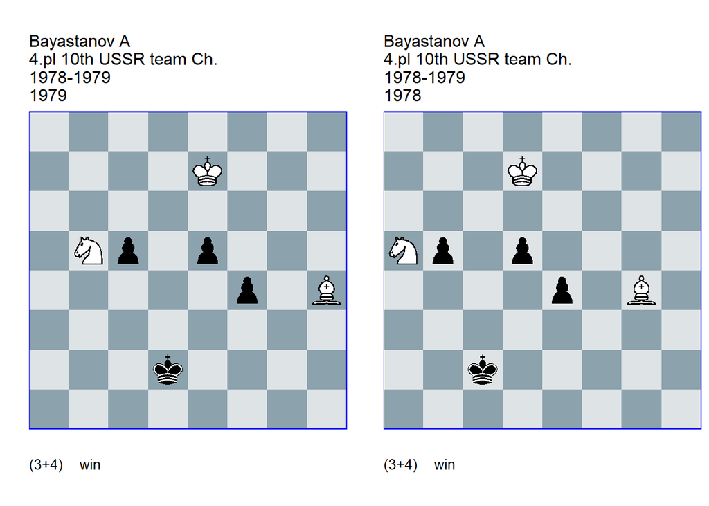

GBR: +0011.03e7d2 TT U3 FEN: 8/4K3/8/1Np1p3/5p1B/8/3k4/8 w - - 0 1

(EG#04137); source: Bulletin USSR otb champ no.7 1979; U3: Pallier=A EG=147 1/ 2007 **1. Kd6** (1. Bg5? Kd3 2. Kd6 f3 3. Bh4 e4) **1… e4 2. Kxc5** (2. Bg5? e3 3. Bxf4 c4 (3… Kd3? 4. Bg3 e2 5. Be1 Kc2 6. Nc3! (6. Ba5? c4 7. Nd4+ Kd3 8. Nf3 c3))) **2… f3** (2… e3 main 3. Nd4 e2 4. Nf3+ Ke3 5. Ne1 (5. Nh2? Kd2 6. Nf3+ Ke3) 5… f3 6. Kd5 (6. Bg5+? Kf2 7. Bh4+ Ke3) 6… f2 7. Bg5# ) **3. Nd4 Kd3 4. Kd5 Ke3 5. Kc4 f2** (5… Kd2! **cook** AP) **6. Bg5# 1-0**.

GBR: +0011.03d7c2 C TT FEN: 8/3K4/8/Np1p4/4p1B1/8/2k5/8 w - - 0 1

source: Bulletin USSR otb champ no.7 1978; (c): Garcia=M (Estudios Artisticos de Ajedrez - I-26 2012) **1. Kc6** (1. Bf5? Kc3 2. Kc6 e3 3. Bg4 d4) **1… d4 2. Kxb5** (2. Bf5? d3 3. Bxe4 Kc3 4. Bf3 Kc2) **2… e3** (2… d3 main 3. Nc4 d2 4. Ne3+ Kd3 5. Nd1 (5. Ng2? Kc2 6. Ne3+ Kd3) 5… e3 6. Kc5! (6. Bf5+? Kd4 7. Bg4 Kd3) 6… e2 7. Bf5#) **3. Nc4 Kd3 4. Kb4 e2** (4… Kc2 5. Bh5) **5. Bf5# 1-0**.

# 2 Recent awards and publications

## 2.1 Steffen Nielsen 50-JT (2026)

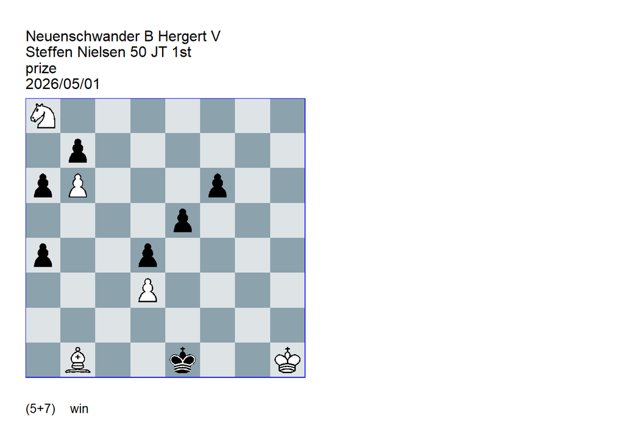

GBR: +0011.26h1e1 FEN: N7/1p6/pP3p2/4p3/p2p4/3P4/8/1B2k2K w - - 0 1

**1. Nc7!** (1. Kg2? e4! (or 1. ..a3 2.Nc7 e4! etc) 2. dxe4 a3 3. Nc7 d3! 4. Nd5 d2 5. Nc3 d1=Q 6. Nxd1 Kxd1 and White must fight for the draw: 7. Ba2! Kc1 8. Bd5 Kb1 9. e5! fxe5 10. Bxb7 a2 11. Be4+ Kc1 12. b7 a1=Q 13. b8=Q!1) **1… e4!** Black defends actively by creating another passed pawn. (1… Kd2 2. Kg2! Kc1 3. Ba2 +-) (1… f5 2. Ne6 +-) **2. dxe4** (2. Nxa6?? e3 -+) (2. Ne6? Kd2! 3. dxe4 Kc1 4. Bd3 (4. Ba2 d3!1) 4… Kb2! 5. Nxd4 Kc3 6. Bxa6 Kxd4 7. Bxb7 Kc5 8. Bd5 Kxb6!1) **2… a3 3. Nxa6!** (3. Nd5? d3! 4. Nc3 d2 5. Bc2 d1=Q 6. Bxd1 Kd2 7. Nb1+ Kxd1 8. Nxa3 Kd2! 9. Nc4+ Kc3! 10. Nd6 Kb4! 11. Nxb7 Kb5 12. Nd6+ Kxb6!1) **3… d3!** Black’s only chance is to continue playing actively. **4. Bxd3 a2 5. Nb4 a1=Q 6. Nc2+ Kd2+ 7. Nxa1** So, the knight has moved from the a8 corner to the a1 corner! But only half of the job is done… **7… Kxd3 8. Nc2!** (8. Nb3? Kxe4 9. Nc5+ Kd5 10. Nxb7 Kc6 11. Na5+ Kxb6!1) **8… Kxe4** (8… Kxc2 9. Kg2 Kd3 10. Kf3 Kd4 11. Kf4 Kc5 12. Kf5 +-) **9. Nb4 Kd4 10. Na6! Kc4 11. Nc7 Kc5 12. Na8** Switchback to a8! The knight has moved back to a8 exactly on the same path it took to a1 in the first place! **1-0**.

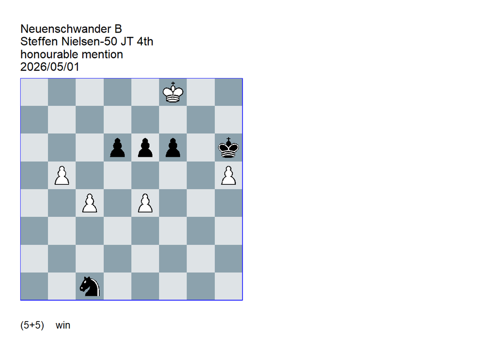

GBR: +0003.43f8h6 FEN: 5K2/8/3ppp1k/1P5P/2P1P3/8/8/2n5 w - - 0 1

**1. e5!** (1. b6? Nb3 2. Ke7 (2. b7 Nc5) 2… Na5 =) (1. Ke7? Nb3 2. Kxd6 f5 =) (1. c5? dxc5 2. b6 (2. e5 f5!) 2… Nd3 3. b7 Ne5 4. Ke7 Nc6+ 5. Kd6 Nb8 6. Kc7 Na6+ 7. Kb6 Nb8 =) **1… fxe5** (1… dxe5 2nd mainline 2. c5 e4 3. c6 (3. b6? Nd3 -+) 3… e3 4. b6!! theme: delayed queening! (4. c7? e2 5. c8=Q e1=Q 6. b6 Qb4+ =) 4… e2 5. b7 e1=Q 6. b8=Q Qc3 7. Qe8 Qc5+ 8. Kg8 Qg5+ 9. Qg6+ 1-0**. )** 2. c5! e4** (2… dxc5 3. b6 +- Nb3 4. b7) **3. c6** ( 3. cxd6? e3 4. d7 e2 5. d8=Q e1=Q =) **3… e3 4. c7** (4. b6 (minor **dual**) transposes to the **main** line ) **4… e2 5. b6!!** theme: very delayed queening! (5. c8=Q? e1=Q 6. b6 Qf2+ =) **5… e1=Q 6. b7 Qf2+** (6… Qf1+ 7. Ke7! +-) **7. Ke8!** (7. Ke7? Qh4+ 8. Kd7 Nd3 9. c8=Q Nc5+ 10. Kxd6 Qd4+) **7… Nd3 8. c8=Q** (8. b8=Q? Ne5 9. c8=Q Qf7+ 10. Kd8 Qf8+ 11. Kc7 Qe7+ -/+) **8… Ne5** (8… Nc5 9. b8=Q) **9. Qxe6+ Kxh5 10. b8=Q 1-0**.

> Stefffen Nielsen: “The dual 4. b6 takes about 50 percent of the air out of this study. Without it (perhaps with a different introduction), it would have been a prizewinner.”

## 2.2 Phenix (2025)

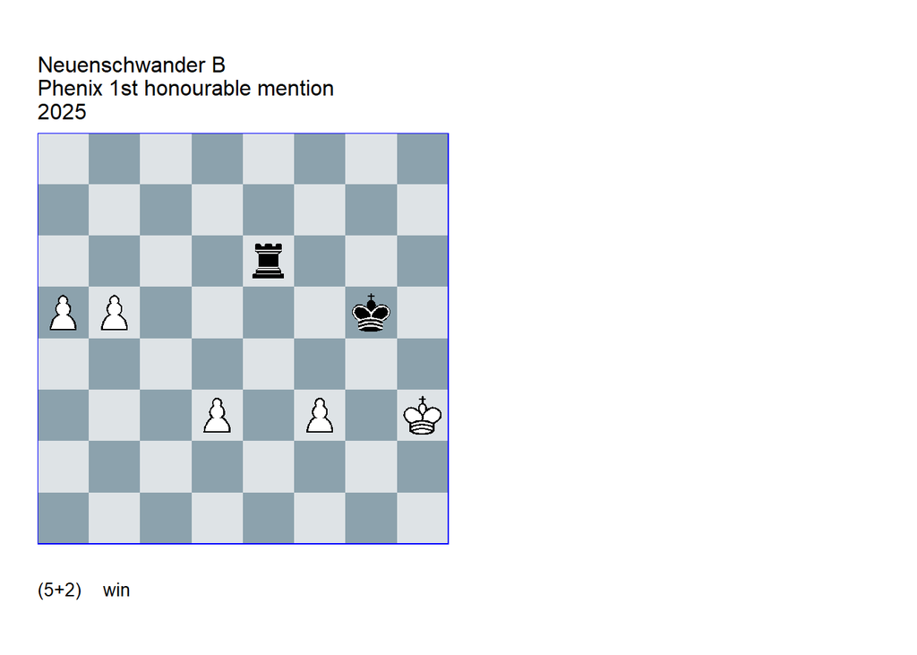

GBR: +0300.40h3g5 FEN: 8/8/4r3/PP4k1/8/3P1P1K/8/8 w - - 0 1

**1. b6!** ( Try: 1. a6? Kf4 2. a7 Re8 3. Kg2 (3. b6 Kxf3 4. Kh4 Kf4 5. Kh5 Kf5 6. Kh6 Kf6 7. Kh7 Re7+) 3… Re2+! 4. Kf1 Ra2 5. b6 Kxf3 6. Ke1 Ke3 7. Kd1 Kxd3 8. Kc1 Kc3 9. Kb1 Ra6 10. b7 Rb6+ 11. Kc1 Rh6! 12. Kd1 Kd3 13. Ke1 Ke3 14. Kf1 Kf3 15. Kg1 Rg6+ =) **1… Kf4 2. b7 Re8 3. Kg2!** (3. a6 Kxf3 4. Kh4 Kf4 etc. ) **3… Ke3** The other black resource. (3… Re2+ The defence in the try does not work here 4. Kf1 Rb2 5. a6 Kxf3 6. Ke1 Ke3 7. Kd1 Kxd3 8. Kc1 +- gains the decisive tempo ) **4. a6 Rg8+ 5. Kh3!** (5. Kf1? Kxf3 6. a7 Rh8 7. Ke1 Ke3 8. Kd1 Kxd3 9. Kc1 Kc3 10. Kb1 Rh1+ 11. Ka2 Rh2+ 12. Ka3 Rh1 13. Ka4 Kc4 14. Ka5 Kc5 15. Ka4 Kc4 =) **5… Kxf3 6. Kh4 Kf4 7. Kh5 Kf5 8. Kh6 Kf6 9. Kh7** Tempo gain (Roman theme). **9… Rb8 10. d4 Ke6 11. Kg6! Rg8+ 12. Kh6!** (12. Kh7 Rb8 =time loss ) (12. Kh5 Kf5 13. Kh6 Kf6 14. Kh7 Rb8 =time loss ) **12… Kf6 13. Kh7** Final decisive tempo gain. **13… Rb8 14. d5 Ke5 15. Kg6 Rg8+ 16. Kf7 Rb8 17. Ke7 Kxd5 18. Kd7 Kc5 19. Kc7 1-0**.

> Volker Hergert: “Another fine example of a miniature from the Logical School. In the opening position, the aim is to advance the correct one of the two connected passed pawns. Once again, the answer requires far-sightedness. The subtle difference lies in whether the rook is directed to b2 or a2, meaning that 8.Kc1 represents a tempo gain in one of the critical variations. It is nice that in the solution, 3…Ke3, which was the alternative to the main move in the temptation, becomes Black’s most tenacious defence, forcing White to find the counter-intuitive move 5.Kh3! The ensuing play is characterised by the black king continuously moving into close opposition to the white king, which is moving along the edge, and repeatedly threatening mate. Black cannot, however, continue this strategy indefinitely, because the white king eventually gains a tempo by attacking the rook. This pattern is fundamentally familiar, but is shown here in a refreshingly new way in conjunction with a specific arrangement of white passed pawns. White can use the king’s tempo gains to advance the d-pawn. Although this pawn is ultimately lost, the forced movement of the black king allows the white king to make the decisive incursion across the seventh rank. Very instructive, albeit rather technical in nature, with no major highlights and no significant black counterplay, which, in my opinion, stands in the way of this otherwise very fine work receiving a prize.”

## 2.3 The Problemist (2026)

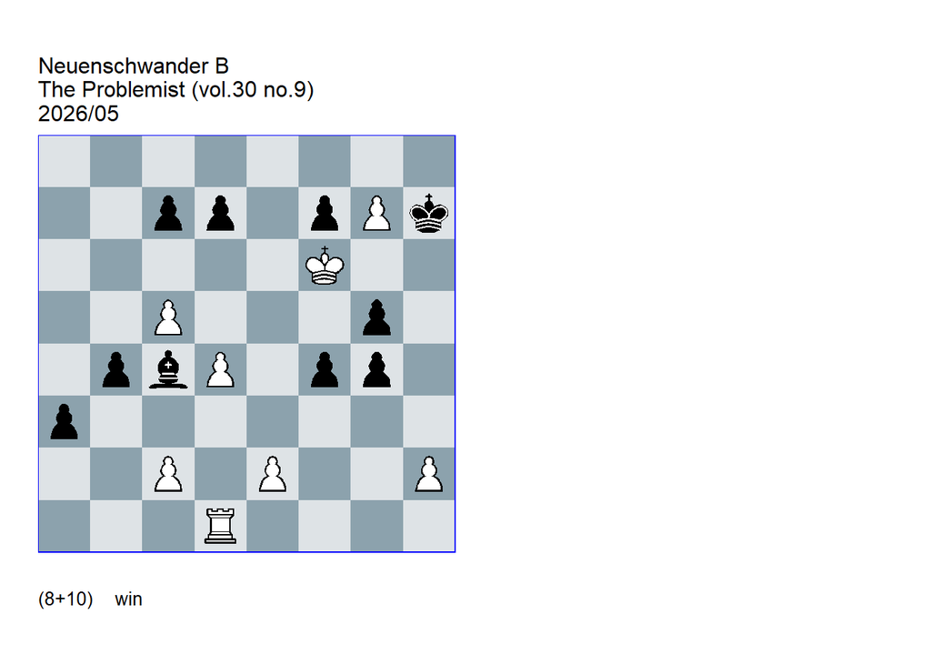

GBR: +0130.68f6h7 FEN: 8/2pp1pPk/5K2/2P3p1/1pbP1pp1/p7/2P1P2P/3R4 w - - 0 1

**1. c6!** (1. d5? Kg8 -/+) (1. h4? a2 (1… gxh4? 2. Rg1 Be6 (2… g3 3. Rh1 +-) 3. d5 +-) ) **1… dxc6** (1… d6 2. c3! a2 (2… b3 3. d5 Kg8 4. Rd4 +-) (2… f3 3. cxb4 f2 4. b5 Bxb5 5. Kxf7 Bc4+ 6. Kf8 +-) 3. cxb4 f3 4. b5 fxe2 5. Rc1 +-) **2. d5! cxd5 3. Rh1! d4 4. h4! Bd5 5. c4!** (5. e4? Bxe4! (5… fxe3? 6. c4! dxc3 would lead to the mainline ) (5… dxe3? 6. c4! +-) 6. c4 (6. Re1 a2 =) 6… bxc3 = The bishop on e4 prevents the black rook from entering vie the b-line (6… dxc3? 7. Rd1 +-) ) **5… dxc3** (5… bxc3 6. Rb1 +-) **6. e4!** (6. Rd1? a2 -+) **6… fxe3 7. Rh2 g3 8. Rh3 g4 9. Rxg3** Now Black is helpless against the rook’s attack via the h-file or the 8th rank. **9… Be6** (9… a2 main 10. Rxg4 Kg8 11. Rxb4 a1=Q 12. Rb8+) **10. Rxe3 a2 11. Re5 a1=Q 12. Rh5+** Five powerful pawn moves pave the way for White’s mating attack **1-0**.

## 2.4 EG (2026)

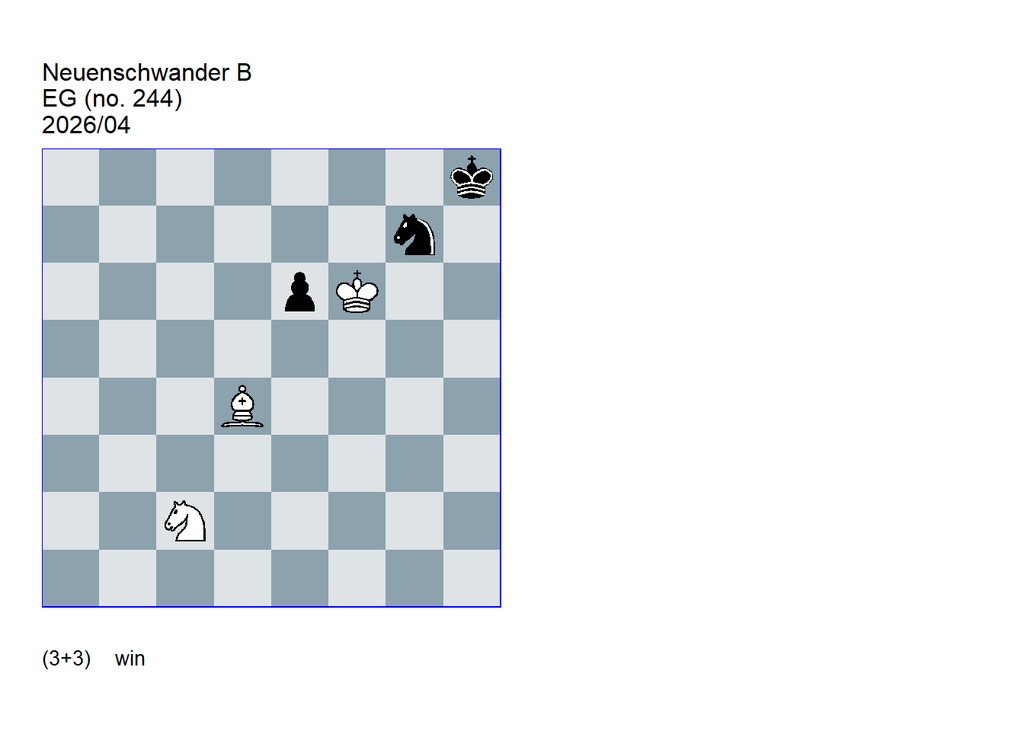

GBR: +0014.01f6h8 FEN: 7k/6n1/4pK2/8/3B4/8/2N5/8 w - - 0 1

**1. Kf7!** Two stalemates save Black after the thematic try 1.Kg6. (1. Kg6? e5 2. Bxe5 Kg8 3. Nd4 (3. Bxg7 stalemate ) 3… Ne6! 4. Nxe6 stalemate ( 4. Nc6 Nf8+ =) ) **1… e5 2. Bxe5 Kh7 3. Bd6!** (3. Ne3? Nf5! like in the thematic try ) (3. Bf4? Nf5 =) **3… Nf5 4. Bf8 Nh4** The strongest defence. (4… Nh6+ 5. Kf6 Ng4+ 6. Kf5 leads to the position in the mainline (move 10) ) **5. Nd4** (5. Ne3? Nf3! =) **5… Ng6 6. Bg7 Nh8+** (6… Nf4 7. Nf3 Ne6 8. Bb2 Ng7 (8… Nd8+ 9. Ke7 +-) 9. Bc1 Nf5 10. Kf6 Ng7 11. Ng5+ Kg8 12. Ba3) **7. Kf6** (7. Kf8? Nf7! =) **7… Nf7** (7… Kg8 8. Bh6 Nf7 9. Bf4 +- ) (7… Ng6 8. Ne6 Kg8 9. Bh6 Kh7 10. Bd2 +-) **8. Bf8** (8. Nf3? Kg8! =) **8… Nh6 9. Nc2!!** One of these “invisible moves”: the white knight not only moves away from the action, it also came from c2 on move 5 (switchback)! (9. Kg5 loses time 9… Nf7+ 10. Kf6 Nh6) **9… Ng4+ 10. Kf5** (10. Kg5? Ne5 =) **10… Nh6+** (10… Nh2 11. Kf4 +-) **11. Kg5 Nf7+ 12. Kf6 Nh6** (12… Kg8 13. Bb4 Nh6 14. Ne3 Nf7 15. Nf5 +-) **13. Ne3** and White wins easily, e.g., **13… Ng8+ 14. Kg5 Kh8 15. Kg6 1-0**.

## 2.5 Schweizerische Schachzeitung (2026)

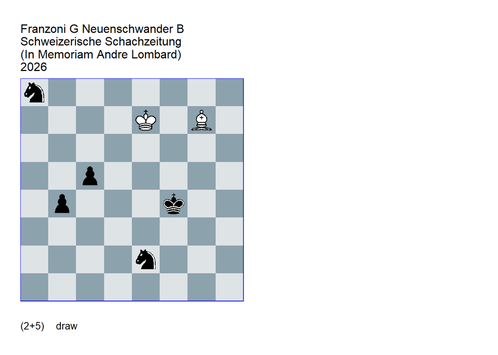

GBR: =0016.02e7f4 FEN: n7/4K1B1/8/2p5/1p3k2/8/4n3/8 w - - 0 1

**1. Kd6** That the c1 is under control due ot Bh6+ gives White hope…. **1… c4 2. Kc5 c3 3. Kxb4 c2 4. Kb3 c1=N+** Three knights win against one bishop. White must exchange the bishop against one of the knights. **5. Kc2 Ke4 6. Kd2!** (6. Kd1? Kd3 -+) (6. Bb2? Nd3 -+) **6… Kf3 7. Kc2!** Otherwise the knight escapes via b3. **7… Na2 8. Kb3 Nac1+** (8… Nec1+ 9. Kb2! and Bh6 ) **9. Kc2 Ke4 10. Kd2 Nb6 11. Bh6!!** The most difficult move of the study: the threat is Ke1 (Kd1) (11. Bb2? Nc4+ 12. Kc2 Nd3 -+) **11… Kf3** (11… Nc4+ 12. Ke1! = (12. Kd1? Nb2+ 13. Kc2 (13. Ke1 Nbd3+ -+) 13… Ncd3 -+) ) **12. Kc2 Na2 13. Bd2!** and the white king attacks the knight on a2 in the next move, after which White escapes by a bishop-knight exchange . (13. Kb3? Nac3! -+) **1/2-1/2**.

## 2.6 Probleemblad (2025, 2026)

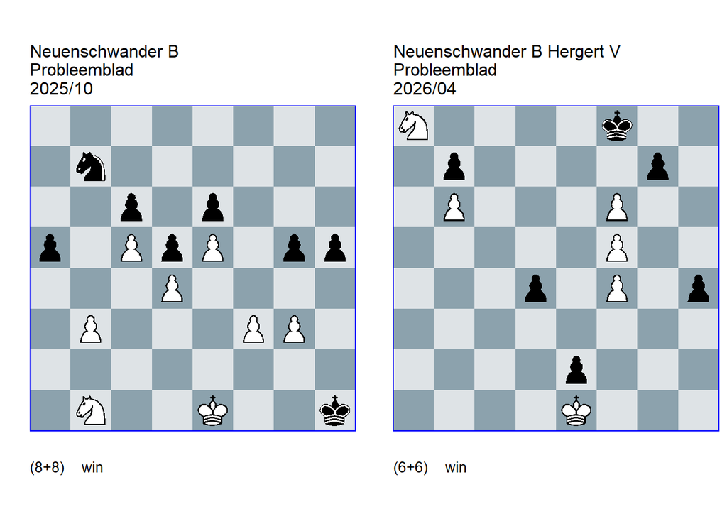

GBR: +0004.66e1h1 FEN: 8/1n6/2p1p3/p1PpP1pp/3P4/1P3PP1/8/1N2K2k w - - 0 1

**1. Kf2 Nd8** (1… Kh2 2. f4 gxf4 3. gxf4 Nd8 (3… Kh3 4. f5) 4. Nc3 Kh3 5. Kf3 Kh4 6. Nd1! Nf7 7. Ne3 Nh6 8. f5 Kg5 9. f6 Nf7 10. Nc2 Kf5 11. b4 +/-) **2. Nc3!** (2. f4? Nf7 3. f5 exf5 4. e6 Nh6 5. e7 Ng4+ and Black holds ) **2… Kh2** ( 2… Nf7 3. Nxd5 cxd5 (3… exd5 4. e6 +-) 4. c6 +-) **3. f4!** ( After 3. Ne2? Nf7 4. f4 Kh3! 5. f5 Nd8 6. f6 Kg4 7. Kg2 Kf5 8. Kf3 Kg6 Black keeps the balance ) **3… Nf7** (3… gxf4 4. gxf4 Kh3 5. Kf3 Kh4 6. Nd1! etc., see 1…. Kh2 ) **4. f5!** (4. Nxd5? exd5! 5. e6 gxf4! 6. exf7 fxg3+ 7. Ke2 Kg2 =) **4… exf5 5. g4!!** (5. e6? Nh6 6. e7 Ng4+ 7. Kf3 Nf6 and Black holds ) **5… hxg4 6. e6 g3+ 7. Ke1! g2 8. Ne2 f4 9. exf7** (9. e7?? f3 10. e8=Q fxe2 11. Qxe2 g4 and Black is better ) **9… f3 10. f8=Q 1-0**.

GBR: +0001.45e1f8 FEN: N4k2/1p4p1/1P3P2/5P2/3p1P1p/8/4p3/4K3 w - - 0 1

**1. Nc7 Kf7** (1… h3 2. Ne6+ Kg8 3. f7+ Kxf7 4. Ng5+ Kf6 5. Nxh3 +-) **2. Ne6 Kxf6 3. Nxd4 h3 4. Nxe2 h2** (4… Kxf5 5. Kf2 Kg4 (5… h2 6. Kg2) 6. Kg1 Kf3 7. Nd4+ Kxf4 8. Kh2 Ke5 9. Nb5 +-) **5. Ng3 h1=Q+ 6. Nxh1** The white knight has reached the diagonally opposing corner square, but only have of the job is done… **6… Kxf5 7. Nf2 Kxf4 8. Nd3+ Ke4 9. Nb4 Kd4 10. Na6 Kd5 11. Nc7+ Kc6 12. Na8** Switchback to the original corner square! **1-0**.

## 2.7 Problem Paradise (2026)

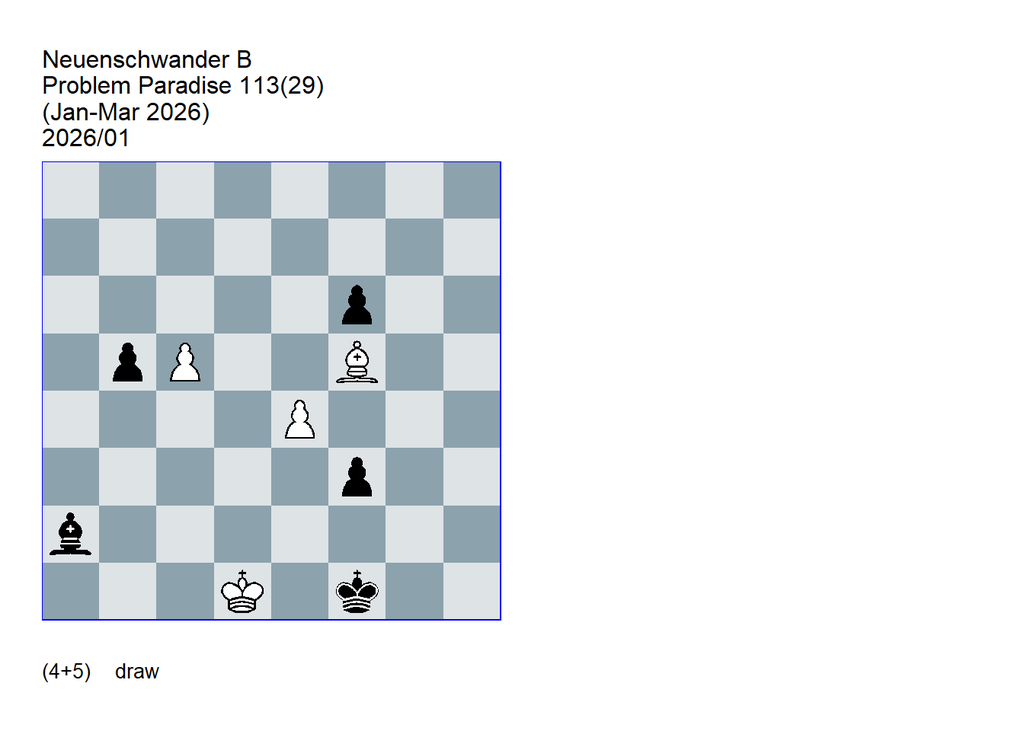

GBR: =0040.23d1f1 FEN: 8/8/5p2/1pP2B2/4P3/5p2/b7/3K1k2 w - - 0 1

**1. e5!** ( Logical try: 1. c6? Kg1 2. c7 f2 3. Bh3 (3. c8=Q f1=Q+ 4. Kc2 Bc4 -+) 3… Be6! 4. Bxe6 f1=Q+ White cannot hold on to the passed pawn, e.g., 5. Kc2 (5. Kd2 Qf4+) 5… Qf2+ 6. Kb1 (6. Kb3 Qg3+) 6… Qe1+ 7. Kb2 Qb4+ -+) **1… fxe5** (1… Kg1 2. exf6 f2 3. Bd3! = (3. Bh3? Be6 -+) ) **2. c6 Kg1** (2… Bd5 3. c7 Bb7 4. Be4 =) **3. c7** (3. Bh3? Bd5 4. c7 Bb7 -+) **3… f2 4. Bh3 Be6 5. Bxe6 f1=Q+ 6. Kd2!** (6. Kc2? Qe2+! 7. Kc3 Qe3+! 8. Kb4 (8. Kb2 Qd4+ 9. Kb3 Qa4+ 10. Kb2 Qb4+) 8… Qe4+! 9. Ka5 Qa8+ 10. Kb6 (10. Kb4 Qa4+ 11. Kc5 Qc2+ 12. Kd6 e4) 10… b4 11. c8=Q Qxc8 12. Bxc8 e4! -+) **6… Qf4+ 7. Ke2! Qe4+ 8. Kd2! Qb4+ 9. Ke2! Qb2+ 10. Kd1! Qb1+ 11. Kd2! Qb4+ 12. Ke2!** Positional draw: despite massive material advantage Black cannot eliminate the passed c-pawn. **1/2-1/2**.

## 2.8 Die Schwalbe (2026)

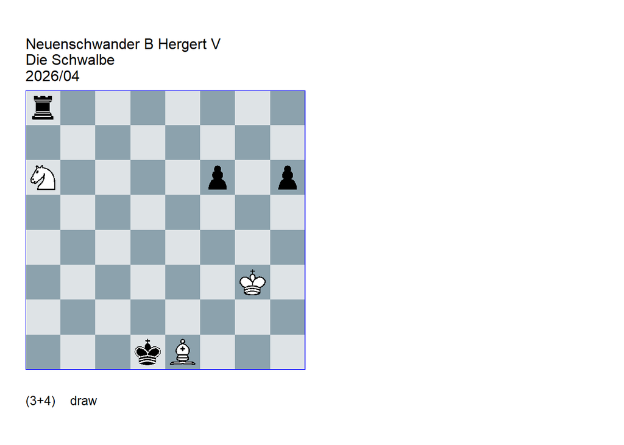

GBR: =0311.02g3d1 FEN: r7/8/N4p1p/8/8/6K1/8/3kB3 w - - 0 1

**1. Nc7 Ra7** (1… Rc8 2. Ba5 =) (1… Rg8+ 2. Kf2 =) **2. Nb5 Rb7 3. Nd6 Rb6** (3… Rd7 4. Bb4 =) (3… Rb3+ 4. Kf2 Rb2+ 5. Kf1 =) **4. Nc4** (4. Nc8? Rb8 -+) **4… Rc6 5. Na5** After the introductory systematic piece movement, the knight is no longer in danger. However, White’s position remains critical.. **5… Rc5 6. Bb4** (6. Bd2? Ke2 7. Bb4 Rg5+ 8. Kh4 Kf3 9. Nc6 Rg4+ 10. Kh5 Rc4 -+) **6… Rb5 7. Bc3** (7. Nc6? Rb6 -+) **7… Kc2 8. Be1 Kd1** (8… Kd3 9. Nc6!1) **9. Bc3 Ke2** (9… Rc5 10. Bb4 Rb5 11. Bc3!1) **10. Nc6 Rc5 11. Nd4+ Ke3** ( 11… Kd3 12. Bb2 =) **12. Bb2 Rg5+ 13. Kh3** (13. Kh4? Rg2 14. Ba1 (14. Bc3 Kd3 -+) 14… Rh2+ 15. Kg4 h5+ 16. Kg3 Rh1 17. Bb2 Rg1+ 18. Kh4 Rb1 -+) **13… f5** (13… Rh5+ 14. Kg3 Rg5+ 15. Kh3 f5 16. Ne6!1) **14. Ne6** (14. Nc2+? Ke4! -+) **14… Rg6 15. Bc1+ Kf3** (15… Ke4 main (echo) 16. Nf4 Rc6 (16… Rg1 17. Ne2 Re1 18. Ng3+ =) 17. Ne2 (17. Bd2? Rc2) 17… Kd3 (17… Rc2 18. Ng3+ Kf3 19. Bxh6 =) 18. Nf4+ Ke4 (18… Kc2 19. Be3 Rc3 20. Nd5 =) 19. Ne2 positional draw ) (15… Kf2 16. Nf4 Rg1 17. Kh2 =) **16. Nd4+ Ke4 17. Ne2** ( 17. Nb3? f4 -+) **17… Kf3 18. Nd4+** (18. Nf4? Rg1 -+) **18… Ke4 19. Ne2** positional draw **1/2-1/2**.

## 2.9 Variantim (2025)

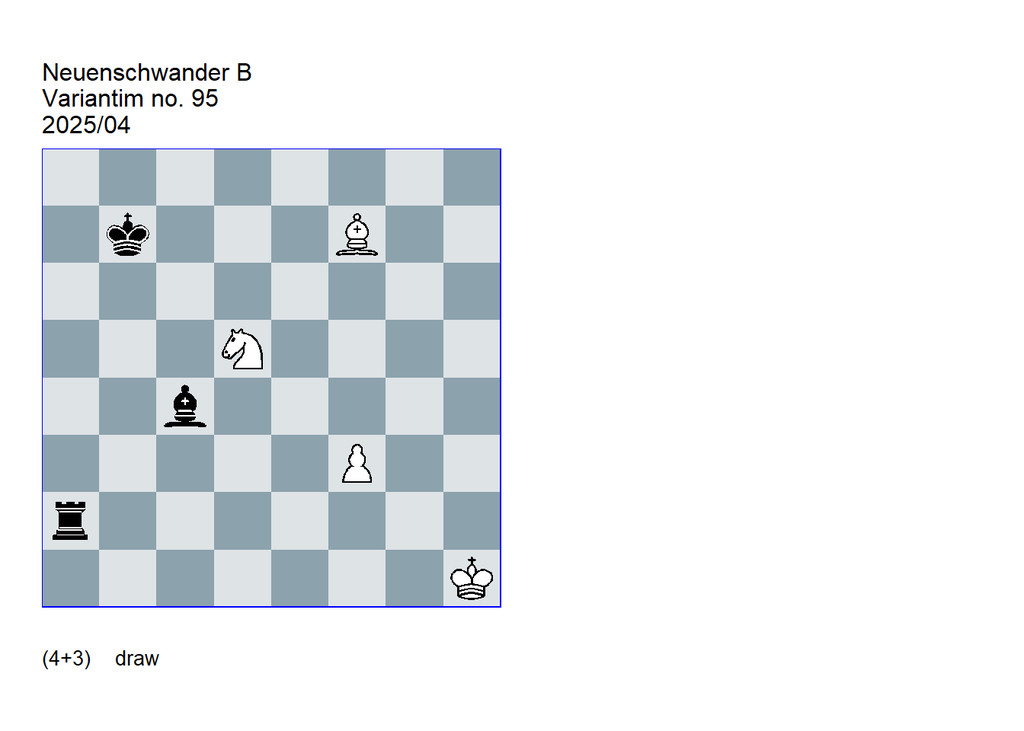

GBR: =0341.10h1b7 FEN: 8/1k3B2/8/3N4/2b5/5P2/r7/7K w - - 0 1

**1. Be6** (1. Bg8? Ra5 2. Nf6 Bxg8 3. Nxg8 Rh5+ 4. Kg2 Rg5+) **1… Ra6** (1… Re2 2. Bc8+! (2. Bg8? Re5) 2… Kxc8 3. Nb6+) **2. Nc7!** Unpinning. (2. Bg8? Ra5) **2… Ra1+ 3. Kh2** (3. Kg2? Bf1+) **3… Ba2!** Forces the white knight back into the pin. **4. Nd5 Re1** (4… Rd1 5. Nf4) **5. Bg8** (5. Bf7? Rd1) **5… Re5** (5… Re8 6. Nf6) **6. f4** (6. Kg3? Rg5+ (6… Bxd5? 7. Kf4) ) (6. Nf6? Bxg8 7. Nxg8 Rh5+ 8. Kg3 Rg5+) **6… Rh5+** (6… Re8 7. Nf6) **7. Kg3 Rh8** (7… Bxd5 8. Kg4) **8. Be6** (8. Bf7? Rd8) **8… Rd8 9. Nc7!** Second unpinning **9… Bb1 10. Nd5!** (10. Nb5? Kb6! 11. Bc4 (11. Nc3 Rd3+) 11… Bd3! 12. Na3 Kc5) **10… Ba2 11. Nc7 Bb1 12. Nd5** positional draw **1/2-1/2**.

# 3 Comments and revisions

## 3.1 Prize winners

**Volker Hergert** has successfully corrected the study

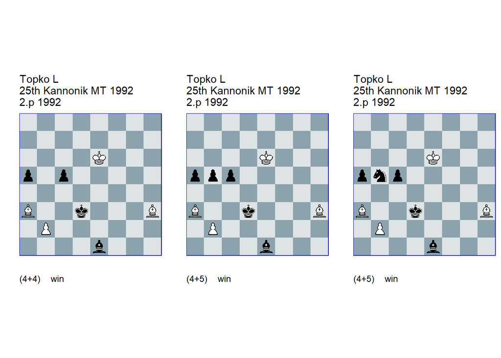

GBR: +0050.12e6d3 U1 U3 FEN: 8/8/4K3/p1p5/8/B2k3B/1P6/4b3 w - - 0 1

source: Chervoni Girnik 1992; (ty also known as: 25th Chervony Girnik 1992); U1; U3: Van, der, Heijden=H HHdbVI 29-7-2016 **1. Bf1+** (1. Kf5! **cook** HH) (1. Bf5+! **cook** HH) **1… Kc2** (1… Kd4! **cook** HH) **2. Bb5 Kb3!** (2… Bb4 3. Ba4+! Kd3 4. Bxb4 axb4 5. b3 c4) **3. Kd5 Bb4** (3… a4! **cook** HH) **4. Ba4+! Kxa4 5. Kc4 Be1** (5… Bxa3 6. b3#) **6. Bxc5 Bb4 7. Be3! Bf8 8. Bc1 Bg7 9. b3# 1-0**.

GBR: +0050.13e6d3 C U3 FEN: 8/8/4K3/ppp5/8/B2k3B/1P6/4b3 w - - 0 1

source: Chervoni Girnik 1992; (ty also known as: 25th Chervony Girnik 1992); (c): (source unknown 0000); U3: Van, der, Heijden=H HHdbVI 20-8-2017 **1. Bf1+** (1. Bxc5? Kc2 2. Bd4 Bd2 3. Bf5+ Kb3 4. Ke5 Bc1 5. Be6+ Kc2 6. b3 Ba3!) **1… Kc2 2. Bxb5 Kb3!** (2… Bb4 3. Ba4+! Kd3 4. Bxb4 axb4 5. b3 c4 6. Bb5) **3. Kd5 Bb4** (3… a4! **cook** HH) **4. Ba4+! Kxa4 5. Kc4! Bxa3** (5… Be1 main 6. Bxc5 Bb4 7. Be3! Bf8 8. Bc1 Bg7 9. b3#) **6. b3# 1-0**.

GBR: +0053.12e6d3 C U3 FEN: 8/8/4K3/pnp5/8/B2k3B/1P6/4b3 w - - 0 1

source: Chervoni Girnik 1992; (ty also known as: 25th Chervony Girnik 1992); (c): (source unknown 0000); U3: Van, der, Heijden=H HHdbVI 29-7-2016 **1. Bf1+ Kc2** (1… Kd4! **cook** HH 2. Bxb5 c4) **2. Bxb5 Kb3!** (2… Bb4 3. Ba4+! Kd3 4. Bxb4 axb4 5. b3 c4) **3. Kd5 Bb4** (3… a4! **cook** HH) **4. Ba4+! Kxa4 5. Kc4! Be1** (5… Bxa3 6. b3#) **6. Bxc5 Bb4 7. Be3! Bf8 8. Bc1 Bg7 9. b3# 1-0**.

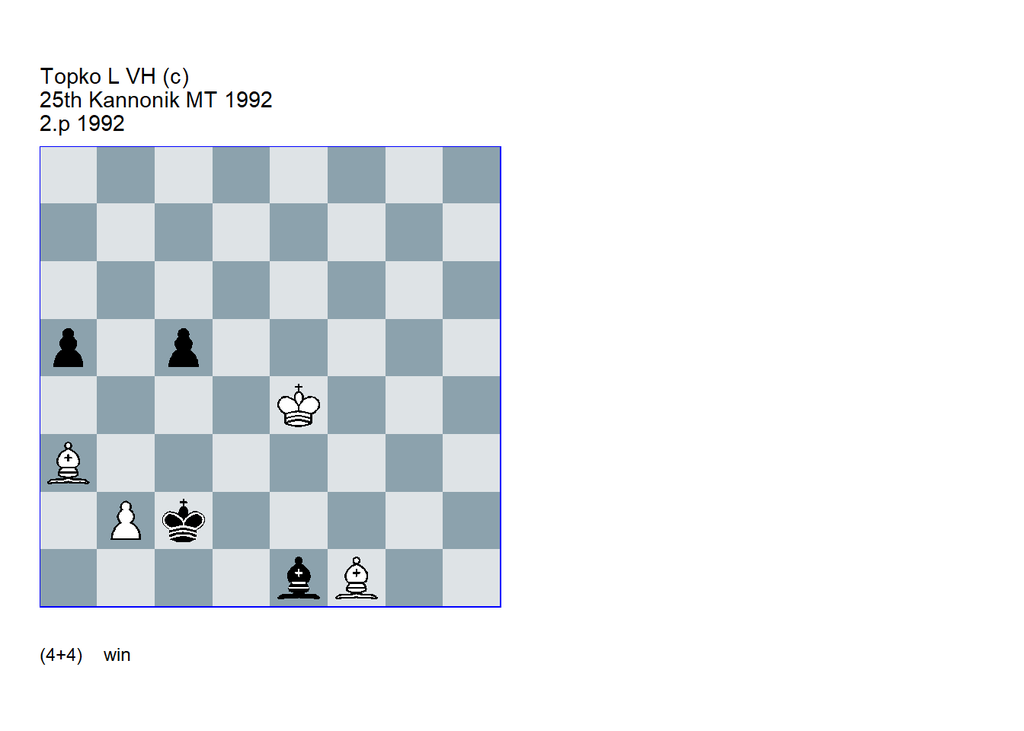

source: Chervoni Girnik 1992; (ty also known as: 25th Chervony Girnik 1992); correction: Hergert=V beatochess no.16 05/2026 (web). **1. Bb5 Kb3 2. Kd3 Bb4 3. Ba4+ Kxa4 4. Kc4 Be1 5. Bxc5 Bb4 6. Be3 Bf8 7. Bc1 Bh6 8. b3# 1-0**.

### 3.1.2 Novikov =0213.03h5a6 (1980). Cook

**5. Rc1+!** cooks the study.

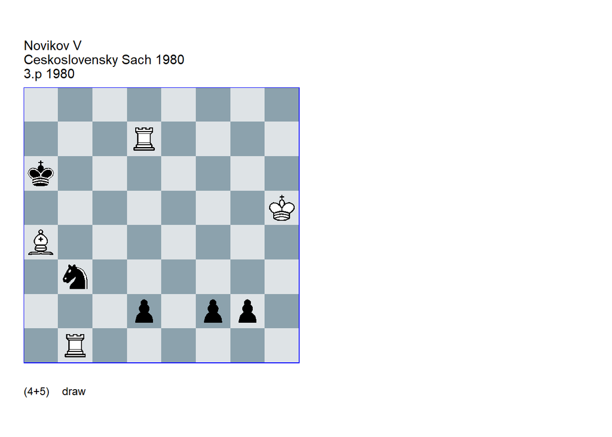

GBR: =0213.03h5a6 U2 FEN: 8/3R4/k7/7K/B7/1n6/3p1pp1/1R6 w - - 0 1

(EG#04893); source: Ceskoslovensky Sach#5813 no.11 11/1980; U2: Neuenschwander=B beatochesss no.16 05/2026 (web). **1. Bb5+** (1. Bxb3? f1=Q 2. Bc4+ Qxc4 3. Rb2 Qf7+) **1… Kxb5 2. Rxb3+ Kc4** (2… Kc6 3. Rdd3 d1=Q+ 4. Rxd1) **3. Rbd3** (3. Rdd3? d1=Q+) **3… d1=Q+ 4. Rxd1 f1=Q 5. Rc7+** (5. Rc1+! **cook** **BN** 5… Kb3 6. Rdd1) **5… Kb3 6. Rcc1 Qf5+ 7. Kh4 Ka2 8. Kg3 1/2-1/2**.

### 3.1.3 Nestorescu +0440.11e5e2 (1980). Cook

**3. Rd3+! Kg4 4. Rd5! Ra6 5. Rd6 Ra5 6. Bb6 Ra6 7. Be3 Ra5 8. Kg2** cooks the modification.

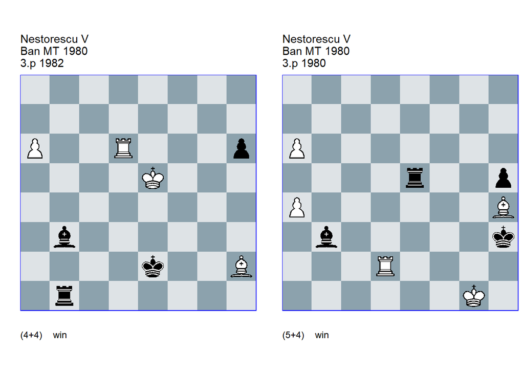

GBR: +0440.11e5e2 U2 FEN: 8/8/P2R3p/4K3/8/1b6/4k2B/1r6 w - - 0 1

(EG#04866); source: Magyar Sakkelet#1499 no.2 2/1982; U2: Van, der, Heijden=H HHdbIII 29-2-2024; Ring ty: 3.pl 18th Romanian Ch. 1981-1982( Revista Romana de Sah no. 7 7/1985) **1. a7 Ra1 2. Bg1 Ra5+ 3. Kf4! Ba4!** (3… Ra4+ 4. Rd4 Ra6 (4… Rxa7 5. Re4+) 5. Rd8) (3… Bc2 4. Rd8 Ra4+ (4… Rf5+ 5. Kg3 Rg5+ 6. Kh4 Be4 7. Re8) 5. Bd4 Kd3 6. Ke5 Ra5+ 7. Bc5+ Kc4 8. a8=Q) **4. Bb6 Ra6 5. Be3!** (5. Bd4? Rxd6 6. a8=Q Rxd4+) **5… Ra5 6. Rd2+ Kf1** (6… Ke1 7. Rd5 Ra6 8. Rd6 Ra5 9. Bd2+) **7. Rf2+!** (7. Rd5 Ra6 8. Rd6 Ra5 9. Bb6 Ra6 10. Bd4 (10. Bc5! **cook** HH 10… Ra5 11. Kf3 h5 (11… Bb3 12. Kg3 Ba4 13. Rd2 Ra6 (13… Bb3 14. Rd8) 14. Rf2+ Ke1 15. Rf6 Ra5 16. Bb4+) 12. Rg6 Bd1+ 13. Ke3 Bb3 14. Rg5! Bc4 15. Kd2 Ra2+ 16. Kc3 Ra4 17. Rf5+ Kg2 18. Rf4) 10… Ra5! 11. Rd5 Ra6 12. Rd8 Bc6 13. Rd6 Ra4! 14. Rxc6 Rxd4+ 15. Kf5 Ra4 16. Rc7 h5) (7. Kg3? Ra6 8. Ra2 (8. Rf2+ Ke1 9. Rf6 Ra5 10. Bb6 Rg5+) 8… Ke1! 9. Kh4 h5! 10. Kg5 (10. Kg3 Rg6+ 11. Kh4 Ra6) 10… Kf1! 11. Kh4! Ke1!) (7. Bb6? Ra6 8. Ra2! h5 9. Ke3 h4 10. Kd4 h3 11. Kc5 Kg1! 12. Rxa4 Rxa7! 13. Kb5+ Kf1 14. Rxa7 h2 15. Rf7+ Kg2) **7… Ke1 8. Rh2! Kf1 9. Rh5!** (9. Kg3? Ra6 10. Rxh6 Ra5 11. Rh5 Ra6 12. Rh8 Rg6+! (12… Bc6? 13. Rh6) 13. Kh2 Bc6) **9… Ra6 10. Rxh6 Ra5 11. Bb6 Ra6 12. Bd4! Ra5 13. Rh5! Ra6 14. Rh8 Bc6 15. Rh6 1-0**.

GBR: +0440.21g1h3 M U2 FEN: 8/8/P7/4r2p/P6B/1b5k/3R4/6K1 w - - 0 1

source: Magyar Sakkelet#1499 no.2 2 /1980; (m): Nestorescu=V (Buletin Problemistic no.56 7-12/1991); Ring ty: 3.pl 18th Romanian Ch. 1981-1982( Revista Romana de Sah no. 7 7/1985); U2: Neuenschwander=B beatochess no.16 05/2026 (web). **1. a7!** (1. Bd8? Bd5! 2. Rxd5 Rxd5 3. Bc7 Rg5+ 4. Kf2 Rg8 5. a7 Ra8 6. Bb8 Kg4 7. Ke3 h4) **1… Ra5** (1… Re8 2. Bd8) **2. Bf2 Bxa4 3. Rd5!** (3. Rd3+? Kg4 4. Rd4+ (4. Rg3+ Kf4! 5. Rd3 Bd7!) (4. Rd5! **cook** **BN** 4… Ra6 5. Rd6 Ra5 6. Bb6 Ra6 7. Be3 Ra5 8. Kg2) 4… Kf3) **3… Ra6 4. Rd6!** (4. Rxh5+? Kg4 5. Rh6 (5. Rh8 Bc6) 5… Ra5 6. Bb6 Ra6 7. Kf2 (7. Bc5 Ra5 8. Kf2 Bd7 9. Rd6 (9. Ke3 Kg5 10. Rd6 Bc8) 9… Bc8 10. Rb6 Bd7 11. Ke3 Kf5 12. Rd6 Bc8 13. Rb6 Rxa7) 7… Bd7 8. Ke3 (8. Bc5 Ra2+ 9. Ke3 Kg5 10. Rd6 Bc8! 11. Rd2 (11. Rb6 Rxa7) 11… Ra6 12. Rb2 Bd7!) 8… Ra3+ 9. Kd4 (9. Ke4 Bf5+ 10. Ke5 Ra4 11. Rh8 (11. Rf6 Re4+ 12. Kd5 Re8) 11… Be4 12. Rg8+ Kh3) 9… Ra4+ 10. Kc5 Bf5 11. Kb5 Bd7+ 12. Kc5 Bf5) **4… Ra5 5. Bb6 Ra6** (5… Rg5+ 6. Kh1! Rg8 7. Rd3+ Kh4 8. Rd4+) **6. Bd4! Ra5 7. Rd5 Ra6 8. Rxh5+** (8. Rd8? Rg6+ 9. Kf2 Bc6) **8… Kg4 9. Rh8 Bc6 10. Rh6 1-0**.

### 3.1.4 Gurgenidze =0800.12g8a8 (1980). Cooks

**8. Rb1!, 10. Rd7** and **11. Rf7!** cook the study.

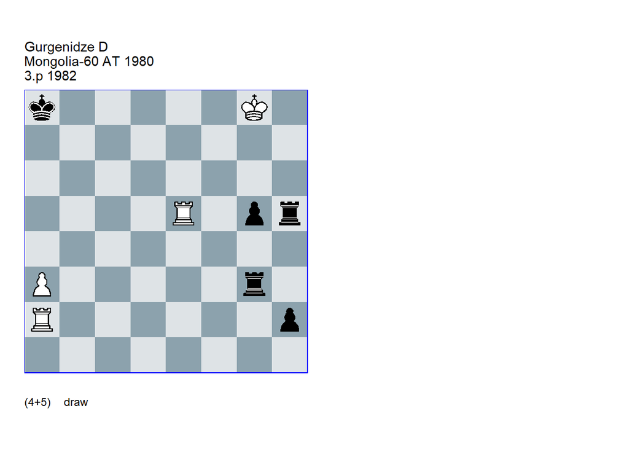

GBR: =0800.12g8a8 U2 FEN: k5K1/8/8/4R1pr/8/P5r1/R6p/8 w - - 0 1

(EG#04760); source: Mongolia 1/1982; U2: Neuenschwander=B, Hergert=V beatochess no.16 05/2026 (web), **1. Rb2 Rh8+** (1… Rxa3 2. Re8+ Ka7 3. Re7+) **2. Kxh8** (2. Kg7? Rxa3) **2… h1=Q+ 3. Kg7 Rxa3 4. Re8+ Ka7 5. Re7+ Ka6 6. Re6+ Ka5 7. Re7! Qa8** (7… Qg1 8. Re5+) **8. Reb7!** (8. Rbb7? Qa6!) (8. Rb1! **cook** **BN** ) **8… Qa6! 9. Rb1!** (9. Re7? Ra1!) **9… g4 10. Re7!** (10. Rd7! **cook** VH ) **10… Qa8** (10… Re3 11. Rd7! Rd3 12. Re7!) **11. Reb7** ( 11. Rf7! **cook** **BN** ) **11… Qa6 12. Re7 1/2-1/2**.

### 3.1.5 Gurgenidze +3101.65b2e5 (1979). Cook, correction

**2. Nxg6+** gives White a clear advantage

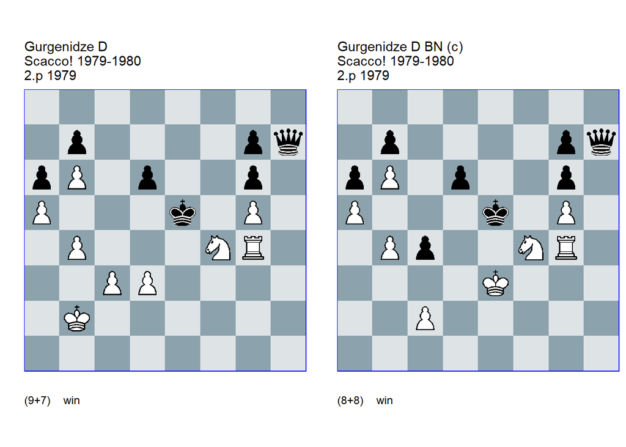

GBR: +3101.65b2e5 U2 FEN: 8/1p4pq/pP1p2p1/P3k1P1/1P3NR1/2PP4/1K6/8 w - - 0 1

(EG#04754); source: Scacco! 11/1979; U2: Neuenschwander=B beatochess no.16 05/2026 (web). **1. Rh4! Qg8** (1… Qxh4 2. Nxg6+) **2. Rh8** (2. Nxg6+ **cook** **BN** 2… Ke6 3. Re4+ Kf7 (3… Kd7 4. Re7+ Kc8 5. Rc7+ Kb8 6. Ne7) 4. Nf4 Qd8 5. g6+ Kf6 6. Kb3 +/-) **2… Qf7** (2… Qxh8 3. Nxg6+) **3. Rf8 Qd7** (3… Qxf8 4. Nxg6+) **4. Nxg6+ Ke6** (4… Kd5 5. Rf5+) **5. Rf6+ Kd5** (5… gxf6 6. Nf8+) **6. Rf5+ Kc6** (6… Qxf5 7. Ne7+) **7. Rc5+ dxc5 8. Ne5+ Kd6** eg **9. Nxd7 Kxd7 10. bxc5 1-0**.

(EG#04754); source: Scacco! 11/1979; correction:: Neuenschwander=B beatochess no.16 05/2026 (web). **1. Rh4 Qg8 2. Rh8 Qf7 3. Rf8 Qd7 4. Nxg6+ Ke6 5. Rf6+ Kd5 6. Rf5+ Kc6 7. Rc5+ 1-0**.

### 3.1.6 Korolkov & Mitrofanov +0013.23c2f5 (1959). No cook! (VH)

**Volker Hergert** informed me that the study is correct. After **6… Kg5**, which is stronger than 6… Kh7 and should therefore be considered the main line, White wins with **7. Nf7+!**; on the other hand, Mario Garcia’s 7. Bd4 would indeed lead to a draw.

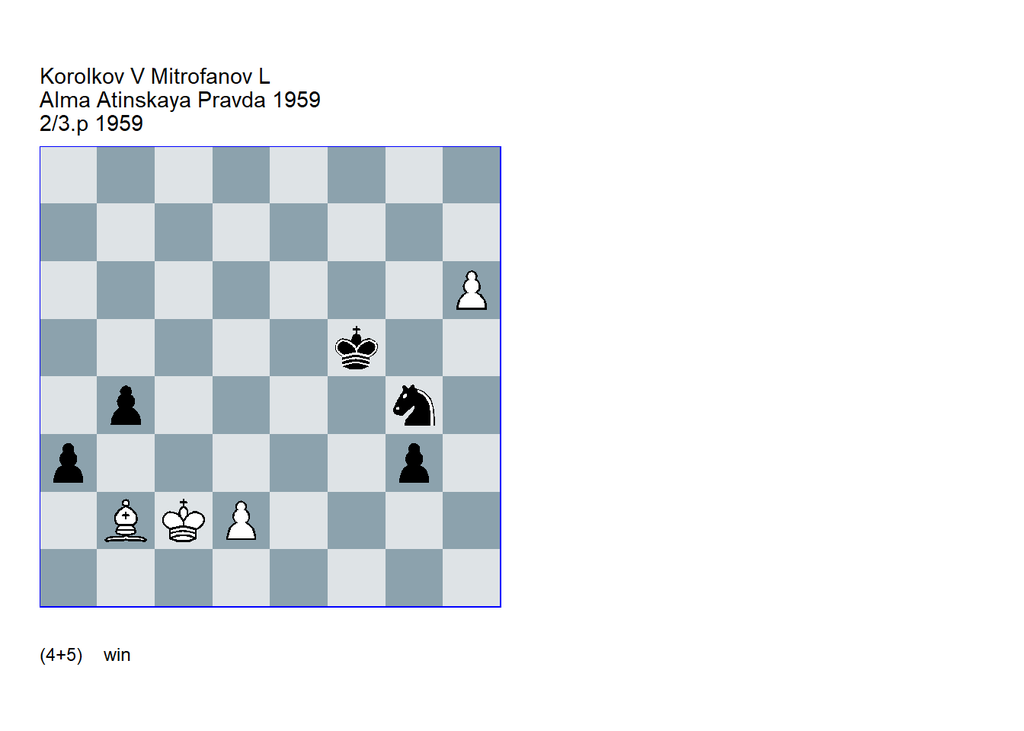

GBR: +0013.23c2f5 FEN: 8/8/7P/5k2/1p4n1/p5p1/1BKP4/8 w - - 0 1

source: Alma Atinskaya Pravda 1959; U3: Garcia=M HHdbV 24-9-2011; no cook!: VH beatochess no.16 05/2026 (web). **1. h7 b3+!** (1… Ne3+ 2. dxe3 g2 3. h8=Q) (1… g2 2. Bd4) **2. Kb1! a2+ 3. Ka1! Ne3! 4. dxe3 g2 5. e4+! Kg6** (5… Kxe4 6. Bd4! Kxd4 7. h8=Q+) **6. h8=N+! Kh7** (6… Kg5! **cook** MG 7. Bd4 ( 7. Nf7+! no **cook**! VH 7… Kf4 8. Bc1+ Kxe4 9. Ng5+ Kd3 10. Nh3 +-) 7… Kf4) **7. Bd4 g1=Q+ 8. Bxg1 Kxh8 9. Bd4+ Kg8 10. Kb2 Kf7 11. Kxb3 1-0**.

### 3.1.7 Kuznetsov +0141.35h2h8 (1979). Cook

**7… Kxd7** followed by **8… Ke7** cook the study..

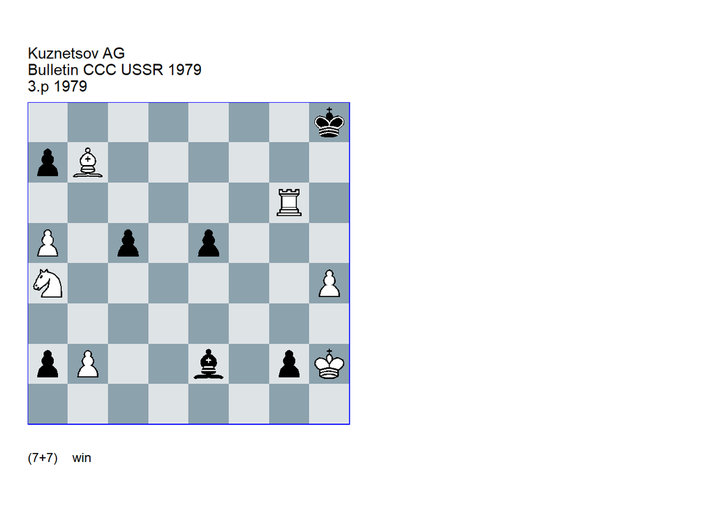

GBR: +0141.35h2h8 U3 FEN: 7k/pB6/6R1/P1p1p3/N6P/8/pP2b1pK/8 w - - 0 1

(EG#04457); source: Bulletin CCC USSR 12/1979; U3: Neuenschwander=B beatochess no.16 05/2026 (web). **1. Rg8+ Kh7** (1… Kxg8 2. Bd5+) **2. Be4+ Kh6 3. Rh8+** (3. Rg6+? Kh5 4. Rg5+ Kxh4) **3… Kg7 4. Rh7+ Kf8** (4… Kf6 5. Rf7+) **5. Rf7+ Ke8** ( 5… Kg8 6. Bd5 g1=Q+ 7. Kxg1 a1=Q+ 8. Rf1+) **6. Bg6** (6. Bc6+? Kd8 7. Rd7+ Kc8 8. Rxa7 g1=Q+ 9. Kxg1 a1=Q+ 10. Kh2 Bg4) **6… Kd8 7. Rd7+ Kc8** (7… Kxd7 8. Nxc5+ Kc6 (8… Ke7! **cook** **BN** 9. Nb3 Bf3) 9. Nb3) **8. Bf5 Kb8 9. Rb7+ Ka8 10. Be4 g1=Q+ 11. Kxg1 a1=Q+ 12. Kh2 Bd3 13. Bc6** (13. Bg2? e4) **13… Qxa4** eg **14. Rb5# 1-0**.

### 3.1.8 Kralin & Neishtadt +0341.42a4e8 (1979). Correction

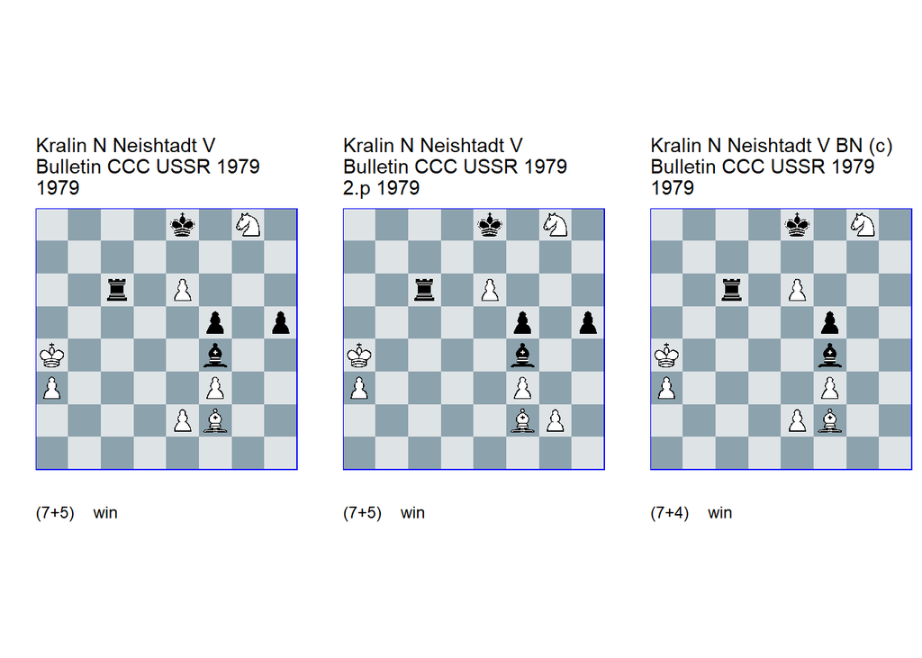

GBR: +0341.42a4e8 U3 FEN: 4k1N1/8/2r1P3/5p1p/K4b2/P4P2/4PB2/8 w - - 0 1

source: Bulletin CCC USSR 6/1979; U3: Kralin=N source unknown 0000 (Shakhmaty v SSSR/8 1981) **1. Nf6+ Kd8 2. e7+ Kxe7 3. Nd5+ Kd7!** (3… Kf7 4. Kb5!) **4. Nxf4 Rc4+ 5. Ka5! Rxf4 6. Kb5! Kc8** (6… Kd8 7. Be3 Rh4 8. Bg5+) (6… Ke6! **cook** NK 7. a4 Kd5 8. a5 Rc4 9. a6 Rc8) **7. a4 Kb7 8. a5 Kc8 9. a6 h4** ( 9… Kb8 10. Bg3) **10. Be3 1-0**.

GBR: +0341.42a4e8 C U3 FEN: 4k1N1/8/2r1P3/5p1p/K4b2/P4P2/5BP1/8 w - - 0 1

(EG#04456); source: Bulletin CCC USSR 6 /1979; (c): (source unknown 0000); U3: Garcia=M HHdbV 24-9-2011 **1. Nf6+ Kf8 2. e7+ Kxe7 3. Nd5+ Kd7** (3… Kf7! **cook** MG 4. Nxf4 Rc4+ 5. Ka5 Rxf4 6. Kb5 Kf6 7. a4 Ke6 8. a5 Kd7 9. a6 Kc8 10. Bc5 Rh4) **4. Nxf4 Rc4+ 5. Ka5 Rxf4 6. Kb5 Kc8** (6… Kd8 7. Be3 Rh4 8. Bg5+) (6… Ke6 7. a4 Kd5 8. a5 Rc4 9. a6 Rc8 10. a7) **7. a4 Kb7 8. a5 Ka8 9. a6 h4** ( 9… Kb8 10. Bg3) **10. Be3 Rg4 11. fxg4 fxg4 12. Bg1 h3 13. g3 1-0**.

GBR: +0341.41a4e8 C FEN: 4k1N1/8/2r1P3/5p2/K4b2/P4P2/4PB2/8 w - - 0 1

source: Bulletin CCC USSR 6/1979; correction: Neuenschwander=B beatochess no.16 05/2026 (web). **1. Nf6+ Kf8 2. e7+ Kxe7 3. Nd5+ Kd7** (3… Kf7 4. Kb5) **4. Nxf4 Rc4+ 5. Ka5! Rxf4 6. Kb5 Kc8 7. a4 Kb7** (7… Kb7 8. a5 Ka8 9. a6) **1-0**.

### 3.1.9 Belokon =1360.24h1d8 (1979). Cook

**15. Qb1!** draws as well.

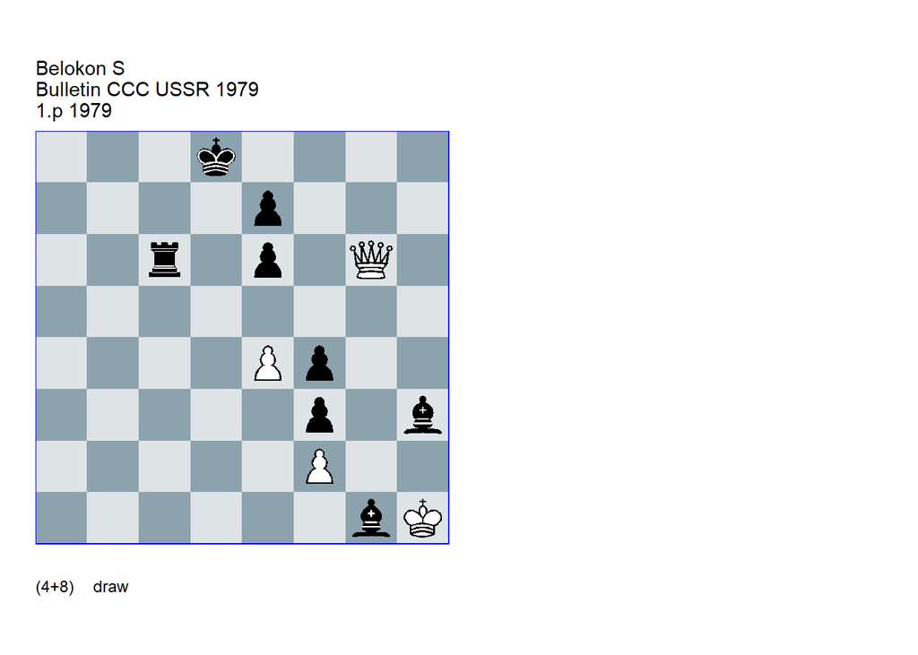

GBR: =1360.24h1d8 U2 FEN: 3k4/4p3/2r1p1Q1/8/4Pp2/5p1b/5P2/6bK w - - 0 1

(EG#04455); source: Bulletin CCC USSR 12/1979; Ring ty: 3/10.pl 15th USSR overall Ch. 1979-1980( 64 Shakhm. Obozrenye no. 20(691) 10/1983); U2: Neuenschwander=B beatochess no.16 05/2026 (web) **1. Qg8+!** (1. Qxg1? Bg2+ 2. Kh2 e5 3. Qd1+ Rd6) **1… Kc7! 2. Qxg1** (2. Kxg1? Rc1+ 3. Kh2 Bg2) **2… Bg2+ 3. Kh2 e5 4. Qc1! Kb7** (4… Rxc1) **5. Qb2+ Rb6 6. Qb1! Ka7 7. Qa2+! Ra6 8. Qa1 Kb7 9. Qb2+ Rb6 10. Qb1 Kc7 11. Qc2+! Rc6 12. Qc1! Kd7 13. Qd1+!** (13. Qd2+? Rd6 14. Qd1 Kd8!) **13… Kc8!** (13… Rd6 14. Qa4+) **14. Kg1!** (14. Qc1? Kc7) **14… Rd6** (14… Rh6 15. Qd7+ Kxd7) **15. Qc2+** (15. Qb1! **cook** **BN** 15… Kd7 16. Qb3) **15… Kd8** (15… Kd7 main 16. Qb3) **16. Qa4! 1/2-1/2**.

### 3.1.10 Mitrofanov +0030.31g7d5 (1980). Correction

A correction that does not simply drop the first move of the original study is possible.

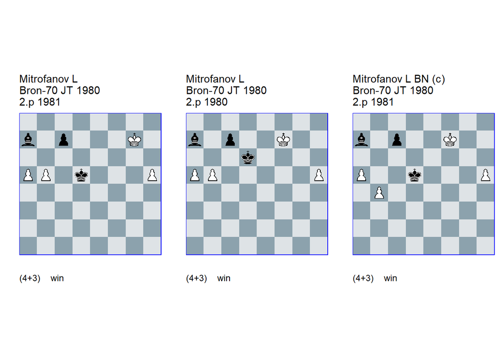

GBR: +0030.31g7d5 U1 FEN: 8/b1p3K1/8/PP1k3P/8/8/8/8 w - - 0 1

(EG#04429); source: EG no.66 11/1981; U1: Van, der, Heijden=H HHdbII 2000; Ring ty: 31/37.pl 16th USSR overall Ch. 1981-1982( Bulletin CCC USSR no. 9(313) 1985) **1. Kf7!** (1. h6? Bd4+) (1. Kg8! **cook** HH 1… Kd6 2. h6 Bd4 3. a6 Kd7 4. h7! (4. b6? Kc8 5. b7+ Kb8 6. Kf7 c6!) 4… Kc8 5. h8=Q Bxh8 6. Kxh8 Kb8 (6… c5 7. bxc6) 7. Kg7 Ka7 8. Kf6! (8. Kf8? Kb6 9. Ke7 c5 10. bxc6 Kxc6) 8… Kb6 9. Ke5 c5 10. Kd5) **1… Kd6** (1… Bd4 2. a6 Kc4 3. b6 Bxb6 4. h6 Kb5 5. h7 Bd4 6. a7) (1… Kc5 2. b6 cxb6 3. h6 Bb8 4. Ke6) **2. h6 Bd4 3. a6 Kd7 4. b6! Kc8! 5. a7 Kb7 6. bxc7 Bxa7 7. Ke6 Kxc7 8. Kd5! 1-0**.

GBR: +0030.31f7d6 C FEN: 8/b1p2K2/3k4/PP5P/8/8/8/8 w - - 0 1

source: EG no.66 11 /1980; (c): (source unknown 0000); Ring ty: 31/37.pl 16th USSR overall Ch. 1981-1982( 64 Shakhm. Obozrenye no. 9(313) 1985) **1. h6** (1. a6? Kd7) **1… Bd4 2. a6** (2. h7? c5) **2… Kd7 3. b6! Kc8** (3… Bxb6 4. h7 Bd4 5. a7) (3… cxb6 4. a7) **4. a7 Kb7 5. bxc7 Bxa7 6. Ke6! Kxc7** (6… Bd4 7. Kd7) **7. Kd5 1-0**.

GBR: +0030.31f7d5 C FEN: 8/b1p2K2/8/P2k3P/1P6/8/8/8 w - - 0 1

EG#04429); source: EG no.66 11/1981; correction: Neuenschwander=B beatochess no.16 05/2026 (web). **1. b5** (1. h6? Bd4) **1… Kd6 2. h6 Bd4 3. a6 Kd7 4. b6! Kc8 5. a7 Kb7 6. bxc7 Bxa7 7. Ke6! Kxc7 8. Kd5! 1-0**.

### 3.1.11 Koranyi +0402.01e6h5 (1980). Comment/cook

Unfortunately White is winning in various ways at the end of the second study, although the thematic mate is the shortest one.

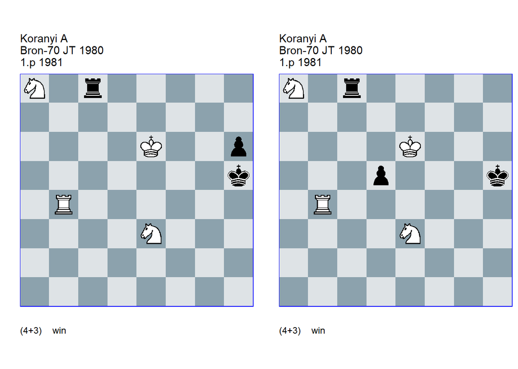

GBR: +0402.01e6h5 TW FEN: N1r5/8/4K2p/7k/1R6/4N3/8/8 w - - 0 1

(EG#04428a); source: EG no.66 11/1981 **1. Nb6!** (1. Nd5? Re8+! 2. Kf5 Rf8+ 3. Nf6+ Rxf6+ 4. Kxf6) **1… Re8+ 2. Kf5 Rxe3 3. Nd5! Rf3+ 4. Nf4+ Kh4** ( 4… Rxf4+ 5. Kxf4! (5. Rxf4?) ) **5. Rb2! h5** (5… Ra3 6. Rh2+ Kg3 7. Rh3+ ) **6. Rh2+** (6. Rg2? Re3! 7. Rg1 Re5+! 8. Kf6 (8. Kg6 Rg5+! 9. Rxg5) 8… Rf5+! 9. Kxf5) **6… Kg3 7. Rg2+ Kh4 8. Rg1! Rf2** (8… Re3 9. Ng2+) (8… Ra3 9. Rh1+ Kg3 10. Rh3+) **9. Rh1+ Kg3 10. Rh3# 1-0**.

GBR: +0402.01e6h5 TW U2 FEN: N1r5/8/4K3/3p3k/1R6/4N3/8/8 w - - 0 1

(EG#04428b); source: EG no.66 11/1981. Comment: Neuenschwander=B beatochess no.16 05/2026 (web). **1. Ng4!** (1. Nxd5? Rxa8 2. Nf6+ Kg6 3. Rg4+ Kh6) **1… Re8+** (1… Rxa8 2. Nf6+ Kh6 3. Rh4+ Kg7 4. Rg4+ Kh8 5. Kf5) **2. Kf5! Rf8+ 3. Nf6+ Kh6** e.g. **4. Rh4+** ( **cook**s **BN** White has many winning moves here) **4… Kg7 5. Rh7# 1-0**.

### 3.1.12 Veretennikov =0046.22b8a6 (1980). Cook, dual, correction

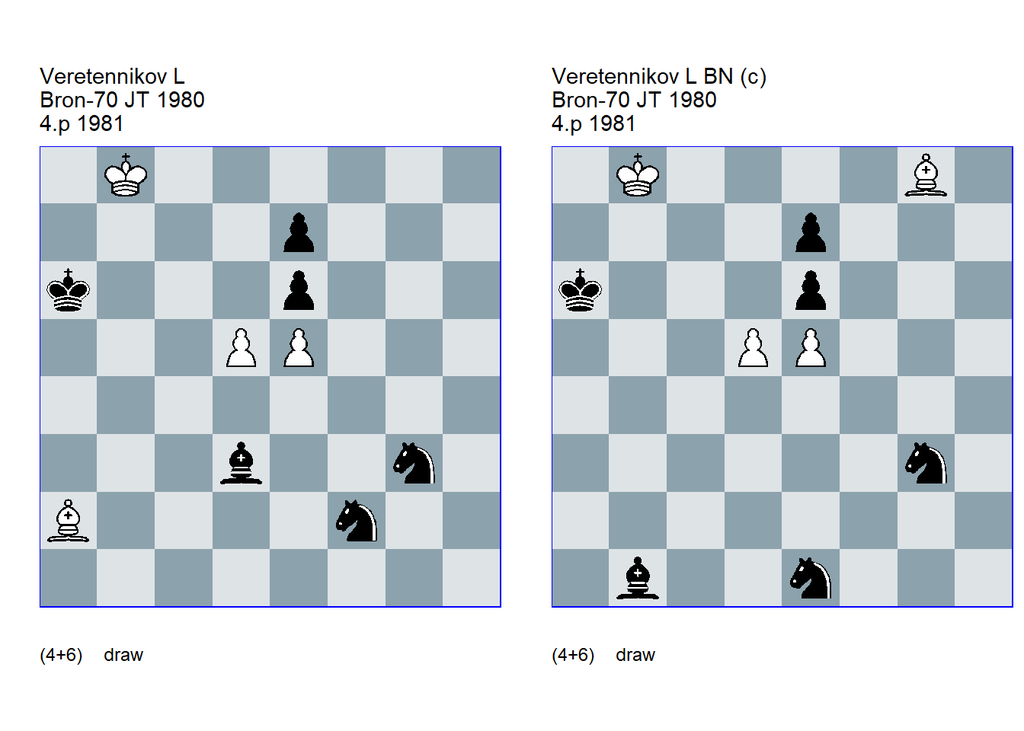

GBR: =0046.22b8a6 (U3) (U2) FEN: 1K6/4p3/k3p3/3PP3/8/3b2n1/B4n2/8 w - - 0 1

(EG#04406); source: EG no.66 11/1981.(U3), (U2): Neuenschwander=B beatochess no.16 05/2026 (web). **1. d6 Ng4** (1… Bb5! **cook**? **BN** 2. Bc4 Bxc4 3. d7 Nf5 4. d8=Q Nd3 -/+) **2. dxe7 Bg6 3. Bxe6** (3. Kc7! **dual** **BN** 3… Nh5 4. Bxe6 Nxe5 5. e8=Q) **3… Nxe5 4. Kc7 Nh5 5. e8=Q Bxe8 6. Kd6 Nf3** (6… Ng6 7. Bd7 Bf7 8. Be6 Be8 9. Bd7) **7. Ke7 Bc6** (7… Bg6 8. Bf7) **8. Kd6 Be8** (8… Be4 9. Bd5) **9. Ke7 Bb5 10. Bg4 1/2-1/2**.

GBR: =0046.22b8a6 C FEN: 1K4B1/4p3/k3p3/3PP3/8/6n1/8/1b2n3 w - - 0 1

(EG#04406); source: EG no.66 11/1981. correction: Neuenschwander=B beatochess no.16 05/2026 (web). **1. d6** (1. Bxe6? Nf3 2. d6 Nxe5 3. d7 (3. dxe7 Nc6+) 3… Nxd7+) **1… Nf3 2. Kc7** (2. dxe7? Bg6 3. Bxe6 Nh5 4. Kc7 Ng7) **2… Nxe5 3. dxe7 Bg6 4. Bxe6 Nh5 5. e8=Q Bxe8 6. Kd6 Nf3 7. Ke7 Bc6 8. Kd6 Be8 9. Ke7 1/2-1/2**.

### 3.1.13 Dobrescu =0074.53f5h8 (1979). Cook

**12. f8=Q** cooks the second correction.

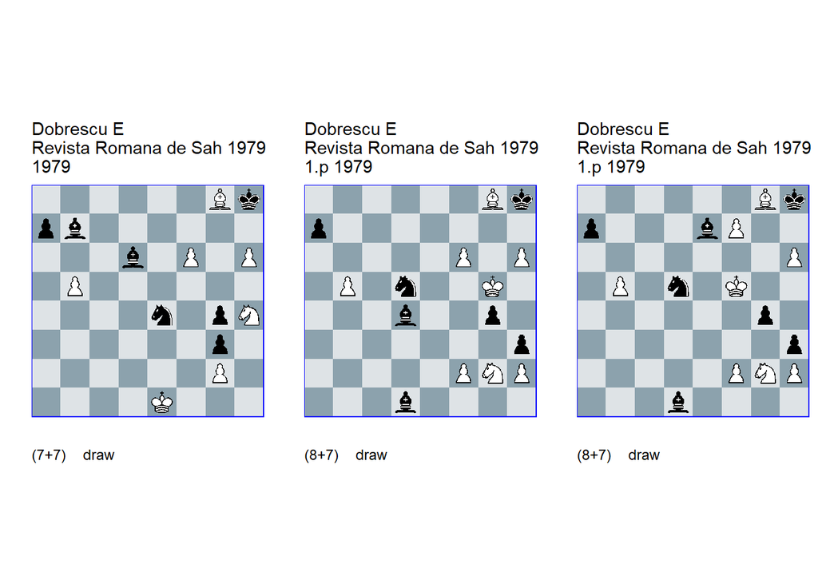

GBR: =0074.43e1h8 U3 FEN: 6Bk/pb6/3b1P1P/1P6/4n1pN/6p1/6P1/4K3 w - - 0 1

source: Revista Romana de Sah#0820 5/1979; U3: Iova=M Revista Romana de Sah/ 10 1979 **1. f7** (1. h7? Bb4+ 2. Ke2 Nc3+ 3. Kd3 Be4+ 4. Kc4 Na2 5. Kb3 (5. b6 axb6 6. Kb5 Bc3! 7. f7 Bb4! 8. Kxb6 Bf8) 5… Bb1 6. Kb2 Nc3 7. Kb3 Bd6! 8. Kb2 Be4 9. Kxc3 Be5+ 10. Kd2 Bxf6) **1… Bb4+ 2. Ke2! Nc3+ 3. Kd3 Be4+ 4. Kc4 Na2! 5. Kb3 Bb1** (5… Bf8! **cook** MI 6. Kxa2 Bxh6 7. f8=Q! (7. Kb3 Kg7 8. f8=Q+ Kxf8 9. Be6 Bg5 10. Nf5 Bxg2 11. Nxg3 Bh4 12. Ne2 Bf3 13. Nd4 Bd1+ 14. Kc4 Bf2) 7… Bxf8 8. Be6 Be7! 9. Nf5 Bxg2! 10. Nxg3 (10. Nxe7 Be4 11. Ng6+ Bxg6 12. Bd5 Bf7! 13. Bxf7 g2) 10… Bf3 11. Nf5 Bc5) **6. Kb2 Nc3 7. Kb3 Nd5 8. Kc4 Be4 9. Kd4 Nf6 10. Ke5 Be7 11. Ke6 Nd5 12. Ke5 Nc3 13. Kd4 Bb4 14. Kc4 1/2-1/2**.

GBR: =0074.53g5h8 C U3 FEN: 6Bk/p7/5P1P/1P1n2K1/3b2p1/7p/5PNP/3b4 w - - 0 1

(EG#04333); source: Revista Romana de Sah#0820 5 /1979; (c): Dobrescu=E (Revista Romana de Sah/1 1980); U3: Van, der, Heijden=H EBUR=1 1/1998; Ring ty: 3.pl 17th Romanian Ch. 1979-1980( Revista Romana de Sah no. 10 10/1983) **1. f7** (1. Bxd5? hxg2 2. Bxg2 Bxf2 3. f7 Bc5) **1… Bf6+** (1… Bg7 2. hxg7+ Kxg7 3. f8=Q+ Kxf8 4. Bxd5) (1… Bc5 2. Nh4 Be7+ (2… Bc2 3. f8=Q) 3. Kf5 Bc2+ 4. Ke6) **2. Kf5** (2. Kh5? hxg2) (2. Kg6? Bc2+ 3. Kh5 hxg2 4. f8=Q Nf4+ 5. Kxg4 g1=Q+) **2… Be7** (2… Bc2+! **cook** HH 3. Ke6 hxg2! 4. f8=Q g1=Q 5. Bf7+ Kh7 6. Bg8+ Kg6 7. Bf7+ Kg5 8. h4+ Kxh4! 9. Kxd5 Qxf2) **3. Nh4 Bc2+ 4. Ke6** (4. Kxg4? Nf6+ 5. Kxh3 Nxg8 6. fxg8=Q+ Kxg8 7. Nf3 Bd3) **4… Be4 5. Ke5** (5. h7? Kg7 6. Ke5 Nc3 7. Kd4 (7. Kf4 Bxh7) 7… Bf6+ 8. Ke3 Kf8 9. Kf4 Bxh7 10. Bxh7 Bxh4 11. Kxg4 Bxf2) **5… Nf6 6. Ke6** (6. f8=Q? Bxf8 7. Bf7 Be7 8. Ke6 (8. Bg6 Nd7+) 8… Ng8 9. Bxg8 Bxh4) **6… Nd5** (6… Nxg8 7. fxg8=Q+ Kxg8 8. Kxe7 Bd3 ( 8… Kh7 9. Kf6 Kxh6 10. Nf5+) 9. Kf6 Bxb5 10. Nf5 a5 11. Ne3 a4 12. Nc2) **7. Ke5 Nc3 8. Kd4** (8. Kf4? Bf8 9. Kxg4 Nxb5) **8… Bb4** (8… Bf8 9. Kxc3 Bxh6 10. Kd4) (8… Bf6+ 9. Kc5 Na4+ 10. Kb4 Be7+ 11. Kxa4) **9. Kc4** (9. f8=Q? Bxf8 10. Be6 Be7 11. Kxc3 Bxh4 12. Bxg4 Bg2) (9. h7? Bc2 10. f8=Q (10. Kc4 Na2) 10… Nxb5+ 11. Kc4 Bxf8 12. Kxb5 Be7) **9… Na2 10. Kb3 Bb1** (10… Bf8 11. Kxa2 Bxh6 12. Kb3 Kg7 13. f8=Q+ Kxf8 14. Be6 Be3 (14… Bf3 15. Nxf3) (14… Bg5 15. Nf5 Bf4 (15… Bf6 16. Nh6) 16. Nd4 Bxh2 17. Bxg4 Bg2 18. Nc6) 15. Bxg4 Bxf2 16. Nf3 Be3 17. Kc4 Ke8 (17… Ke7 18. Nd4 Bg2 19. Nf5+) (17… Kf7 18. Ne5+ Kf6 19. Nd7+) 18. Nd4 Bg2 19. Ne2 Ke7 20. Kd3) **11. Kb2** (11. f4? g3 12. h7 (12. Nf3 Be4) (12. f5 Bxf5) 12… gxh2 13. f8=Q Bxf8 14. Bd5 Be7) (11. f8=Q? Bxf8 12. Be6 Be7 13. Bf5 (13. Nf5 Bf6) 13… Nc1+ 14. Kb2 Bxh4 15. Kxb1 Ne2 16. Bxg4 Nf4) (11. h7? Kg7 12. Kb2 (12. f8=Q+ Bxf8 13. Kb2 Be4 14. Bxa2 Be7 15. Bd5 Bxh7) (12. f4 Bxh7 13. Bxh7 (13. Kxa2 Be4 14. f8=Q+ Bxf8 15. Be6 g3) 13… Kxh7 14. Kxa2 (14. Nf5 Kg6) 14… Kg7 15. Nf5+ (15. Kb3 Be1 16. Nf5+ Kf8) 15… Kf8 16. Ng3 (16. Ne3 g3) (16. Kb3 Be1) 16… Bd6 17. Ne2 Kxf7 18. Kb3 Kf6 19. Kc4 Kf5) 12… Nc3 13. Kb3 (13. f4 Bxh7 14. Bxh7 (14. Kb3 g3 15. Nf3 Be4 16. Ng5 Bd5+ 17. Kxb4 gxh2) 14… Kxh7 15. Kb3 Na2 16. Kxa2 Kg7) 13… Nd5 14. Kc4 (14. f8=Q+ Bxf8 15. Bxd5 Be7) (14. f4 Bf8 15. f5 Nf4) 14… Be4 15. f8=Q+ (15. Kd4 Nf6 16. Ke5 Bxh7) 15… Bxf8 16. Bxd5 Bb1! 17. Be6 Ba2+) **11… Nc3 12. Kb3** (12. f4? g3) (12. h7? Kg7 13. f4 Bxh7) **12… Nd5 13. Kc4** (13. f4? Bf8 14. f5 Nf4) **13… Be4** (13… Ba2+ 14. Kd4 Nf4 15. f8=Q Bxf8 16. Bxa2 Bxh6 ( 16… Ne2+ 17. Ke3) 17. Ke4 Ng2 18. Nf5 Bc1 19. f3) **14. Kd4 Nf6 15. Ke5 Be7** ( 15… Bc3+ 16. Ke6 Bd5+ 17. Kf5) **16. Ke6 1/2-1/2**.

GBR: =0074.53f5h8 C U2 FEN: 6Bk/p3bP2/7P/1P1n1K2/6p1/7p/5PNP/3b4 w - - 0 1

source: Revista Romana de Sah#0820 5 /1979; (c): Dobrescu=E (EBUR no.3 9/1998) ; Ring ty: 3.pl 17th Romanian Ch. 1979-1980( Revista Romana de Sah no. 10 10/ 1983); U2: Neuenschwander=B beatochess no.16 05/2026 (web). **1. Nh4 Bc2+ 2. Ke6** (2. Kxg4? Nf6+ 3. Kxh3 Nxg8 4. fxg8=Q+ Kxg8 5. Nf3 Bd3) **2… Be4 3. Ke5** ( 3. h7? Kg7 4. Ke5 Nc3 5. Kd4 (5. Kf4 Bxh7) 5… Bf6+ 6. Ke3 Kf8 7. Kf4 Bxh7 8. Bxh7 Bxh4 9. Kxg4 Bxf2) **3… Nf6 4. Ke6** (4. f8=Q? Bxf8 5. Bf7 Be7 6. Ke6 ( 6. Bg6 Nd7+) 6… Ng8 7. Bxg8 Bxh4) **4… Nd5** (4… Nxg8 5. fxg8=Q+ Kxg8 6. Kxe7 Bd3 (6… Kh7 7. Kf6 Kxh6 8. Nf5+) 7. Kf6 Bxb5 8. Nf5 a5 9. Ne3 a4 10. Nc2) **5. Ke5 Nc3 6. Kd4** (6. Kf4? Bf8 7. Kxg4 Nxb5) **6… Bb4** (6… Bf6+ 7. Kc5 Na4+ 8. Kb4 Be7+ 9. Kxa4) (6… Bf8 7. Kxc3 Bxh6 8. Kd4) **7. Kc4** (7. f8=Q? Bxf8 8. Be6 Be7 9. Kxc3 Bxh4 10. Bxg4 Bg2) (7. h7? Bc2 8. f8=Q (8. Kc4 Na2) 8… Nxb5+ 9. Kc4 Bxf8 10. Kxb5 Be7) **7… Na2 8. Kb3 Bb1** (8… Bf8 9. Kxa2 Bxh6 10. Kb3 Kg7 11. f8=Q+ Kxf8 12. Be6 Be3 (12… Bf3 13. Nxf3 gxf3 14. Bxh3) (12… Bg5 13. Nf5 Bf4 14. Nd4 Bxh2 15. Bxg4 Bg2 16. Nc6) 13. Bxg4 Bxf2 14. Nf3 Be3 15. Kc4 Ke8 (15… Ke7 16. Nd4 Bg2 17. Nf5+) (15… Kf7 16. Ne5+ Kf6 17. Nd7+) 16. Nd4 Bg2 17. Ne2 Ke7 18. Kd3) **9. Kb2** (9. f4? g3 10. h7 (10. Nf3 Be4) (10. f5 Bxf5) 10… gxh2 11. f8=Q Bxf8 12. Bd5 Be7) (9. f8=Q? Bxf8 10. Be6 Be7 11. Bf5 (11. Nf5 Bf6) 11… Nc1+ 12. Kb2 Bxh4 13. Kxb1 Ne2 14. Bxg4 Nf4) (9. h7? Kg7 10. Kb2 (10. f8=Q+ Bxf8 11. Kb2 Be4 12. Bxa2 Be7 13. Bd5 Bxh7) (10. f4 Bxh7 11. Bxh7 Kxh7 12. Kxa2 Kg7 13. Nf5+ Kf8 14. Ng3 Bd6 15. Ne2 Kxf7 16. Kb3 Kf6 17. Kc4 Kf5) 10… Nc3 11. Kb3 (11. f4 Bxh7 12. Bxh7 Kxh7 13. Kb3 Na2 14. Kxa2 Kg7) 11… Nd5 12. Kc4 (12. f8=Q+ Bxf8 13. Bxd5 Be7) (12. f4 Bf8 13. f5 Nf4) 12… Be4 13. f8=Q+ (13. Kd4 Nf6 14. Ke5 Bxh7) 13… Bxf8 14. Bxd5 Bxh7! (14… Bb1? 15. b6! (15. Be6? Ba2+) 15… axb6 16. Be6) 15. Be6 Kf6 16. Bxg4 Kg5 17. Bxh3 Kxh4) **9… Nc3 10. Kb3** (10. h7? Kg7 11. f4 (11. Kb3 Nd5 ) 11… Bxh7) (10. f4? g3) **10… Nd5 11. Kc4** (11. f4? Bf8 12. f5 Nf4) **11… Be4** (11… Ba2+ 12. Kd4 Nf4 13. f8=Q Bxf8 14. Bxa2 Bxh6 (14… Ne2+ 15. Ke3) 15. Ke4 Ng2 16. Nf5 Bc1 17. f3) **12. Kd4** (12. f8=Q! **cook** **BN** 12… Bxf8 13. Bxd5) **12… Nf6 13. Ke5 Be7** (13… Bc3+ 14. Ke6 Bd5+ (14… Nxg8 15. f8=Q) 15. Kf5) **14. Ke6 1/2-1/2**.

### 3.1.14 Nestorescu =0161.11g1f3 (1979). Cook

**3. Rg6!** cooks the second mainline.

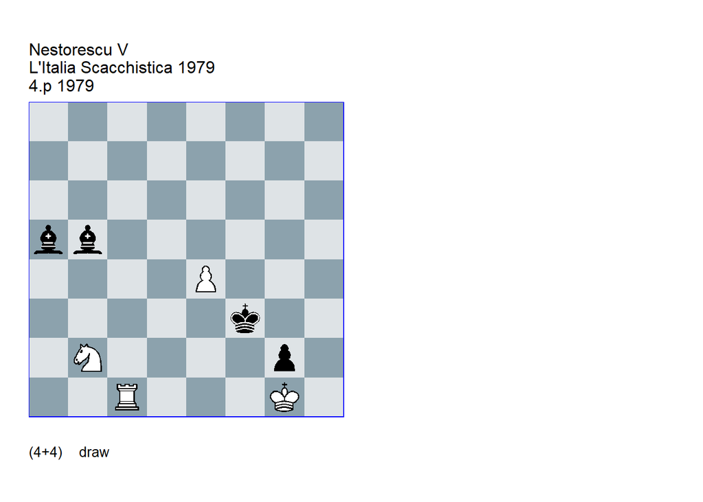

GBR: =0161.11g1f3 U2 FEN: 8/8/8/bb6/4P3/5k2/1N4p1/2R3K1 w - - 0 1

(EG#04267); source: L’Italia Scacchistica#275 no.887 9/1979; U2: Neuenschwander=B beatochess no.16 05/2026 (web). **1. Nd3!** (1. Ra1? Bb6+ 2. Kh2 Bf1 3. Ra3+ Kxe4 4. Rg3 (4. Ra4+ Kf5) 4… Bc7) (1. e5? Bd2 2. Ra1 Be3+ 3. Kh2 Bf1!) **1… Bxd3** (1… Bd2 2. Rc2 Be3+ 3. Nf2) (1… Bb6+ 2. Nc5) **2. Rc6 Bxe4** (2… Bd2 main 3. Rf6+ (3. Rg6! **cook** **BN** 3… Be3+ 4. Kh2 Bf4+ 5. Kg1 Bf1 6. e5) 3… Kg3 4. Rg6+ Kh3 5. Rxg2! (5. Kf2? Bxe4 6. Rg8 ( 6. Rg3+! **cook** **BN** 6… Kh2 7. Rg4) 6… Bc3 7. Rd8 Kh2) 5… Be3+ 6. Kh1 Bxe4) **3. Rf6+!** (3. Rh6? Bd2 4. Rh3+ (4. Rf6+ Kg4 5. Rf2 Be3 6. Kh2 g1=Q+! 7. Kxg1 Kg3) 4… Ke2 5. Rg3 Be3+ 6. Kh2 Kf1!) (3. Re6? Bd8! 4. Ra6 Bg5) **3… Kg4! 4. Re6!** (4. Rf2? Bb6 5. Kh2 g1=Q+!) (4. Ra6? Bb4 5. Ra1 Bc5+ 6. Kh2 Kf3 7. Rc1 Bd6+ 8. Kg1 Bf4 9. Re1 Be3+ 10. Kh2 Bf2 11. Ra1 Bd3) **4… Kh3 5. Rh6+** (5. Kf2? Bb4 6. Re5 Bd6! 7. Rh5+ (7. Rxe4 Bg3+ 8. Kg1 Bh2+ ) 7… Kg4 8. Ra5 (8. Rb5 Bh2) 8… Bc6! 9. Kg1 Kh3) **5… Kg4** (5… Kg3 6. Rg6+ Bxg6) **6. Re6 Kf3 7. Rf6+ Kg4 8. Re6 1/2-1/2**.

### 3.1.15 Matous =3100.22g1a6 (1979). Cooks, correction

The mainlines arising after **1… Qe4** and **1… Qf3** are cooked. The study can be fixed by an additional pawn on f6.

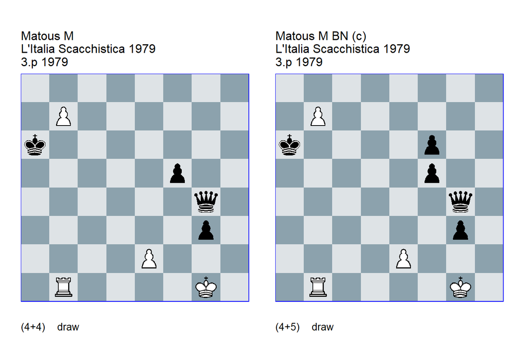

GBR: =3100.22g1a6 U2 FEN: 8/1P6/k7/5p2/6q1/6p1/4P3/1R4K1 w - - 0 1

(EG#04266); source: L’Italia Scacchistica#282 no.889 11/1979; U2: Neuenschwander=B beatochess no.16 05/2026 (web). **1. e3!** (1. b8=N+? Ka5 2. Nc6+ Ka4 3. Rb4+ Qxb4 4. Nxb4 Kxb4 5. Kg2 f4 6. Kf3 Kc3 7. e3 g2! 8. Kxg2 fxe3) (1. b8=Q? Qd4+ 2. Kg2 Qf2+ 3. Kh3 Qh2#) (1. Rb6+? Ka5 2. Rb5+ Ka4 3. e3 Qd1+ 4. Kg2 Qe2+) **1… Qe2** (1… Qf3 main 2. Rb6+! Ka5 3. Rb5+! ( 3. Rb2! **cook** **BN** 3… Qxe3+ 4. Kg2 Qe4+ 5. Kh3 =) 3… Ka4 4. Rb4+ (4. Rb2! **cook** **BN** 4… Qxe3+ 5. Kg2 Qe4+ 6. Kh3 =) ) (1… Qe4 main 2. Rb6+! (2. Rb3? Qc2!) 2… Ka5 3. Rb3! (3. Rb2! **cook** **BN** 3… Qxe3+ 4. Kg2 Qe4+ 5. Kh3) (3. Rb5+ Ka4 4. Rb2 **cook** **BN** ) ) (1… Qh4 2. Rb2 g2 3. b8=N+) **2. b8=N+! Ka7 3. Nc6+ Ka6 4. Nb8+ Ka5 5. Nc6+ Ka6** (5… Ka4 6. Ra1+ ) **6. Nb8+ 1/2-1/2**.

GBR: =3100.23g1a6 C FEN: 8/1P6/k4p2/5p2/6q1/6p1/4P3/1R4K1 w - - 0 1

(EG#04266); source: L’Italia Scacchistica#282 no.889 11/1979; correction: Neuenschwander=B beatochess (web) no.16 05/2026. **1. e3 Qe2** (1… Qe4 main 2. Rb6+ Ka5 3. Rb3! (3. Rb2? Qxe3+ 4. Kg2 Qe4+ 5. Kh3 Qh1+ 6. Kxg3 f4+ 7. Kg4 Qg1+ 8. Kf5 Qg5+) ) (1… Qf3 main 2. Rb6+ Ka5 3. Rb5+ (3. Rb2 Qxe3+ 4. Kg2 Qe4+ 5. Kh3 Qh1+ 6. Kxg3 f4+ 7. Kg4 Qg1+ 8. Kf5 Qg5+) 3… Ka4 4. Rb4+ Ka3 5. Rb3+ Ka2 6. Rb2+ Ka1 7. Rb1+ Kxb1 8. b8=Q+ Kc1 9. Qc7+ Kd1 10. Qd6+ Ke2 11. Qa6+ Kxe3 12. Qd3+) **2. b8=N+ Ka7 3. Nc6+ Ka6 4. Nb8+ Ka5 5. Nc6+ Ka6** (5… Ka4? 6. Ra1+) **6. Nb8+ 1/2-1/2**.